# Nora Master Project Data Analysis Notebook

## Comparison of current inflation and inflation forecast

Frequency

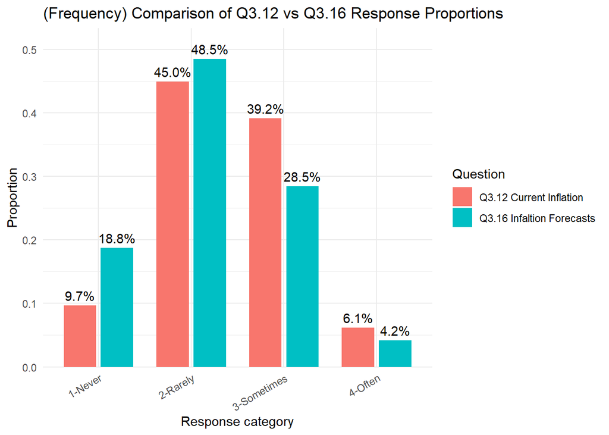

```r
q3_12_long <- q3_12_prop %>%
group_by(`Q3.12_label`) %>%
  rename(choice = `Q3.12_label`) %>%
  summarise(total_count = sum(Count), .groups = "drop") %>%
  mutate(proportion = total_count / sum(total_count),
         question = "Q3.12 Current Inflation")

q3_16_long <- q3_16_prop %>%
  group_by(`Q3.16_label`) %>%
  rename(choice = `Q3.16_label`) %>%
  summarise(total_count = sum(Count), .groups = "drop") %>%
  mutate(proportion = total_count / sum(total_count),
         question = "Q3.16 Infaltion Forecasts")

# bind them together
q3_frequency <- bind_rows(q3_12_long, q3_16_long)

ggplot(q3_frequency, aes(x = choice, y = proportion, fill = question)) +
  geom_col(position = position_dodge(width = 0.8), width = 0.7) +
  geom_text(aes(label = scales::percent(proportion, accuracy = 0.1)),
            position = position_dodge(width = 0.8), vjust = -0.5) +
  scale_y_continuous(
    expand = expansion(mult = c(0, 0.1))
  ) +
  labs(
    title = "(Frequency) Comparison of Q3.12 vs Q3.16 Response Proportions",
    x     = "Response category",
    y     = "Proportion",
    fill  = "Question"
  ) +
  theme_minimal() +
  theme(
    axis.text.x = element_text(angle = 30, hjust = 1)
  )
```

Chi-squared Testing

```r
q3_12_t <- q3_12_table %>%
  rename(choice = `Q3.12`) %>%
  mutate(question = "Q3.12")
q3_16_t <- q3_16_table %>%
  rename(choice = `Q3.16`) %>%
  mutate(question = "Q3.16")
# bind them together
q3_frequency_t <- bind_rows(q3_12_t, q3_16_t)
q3_frequency_table <- table(q3_frequency_t$choice, q3_frequency_t$question)
print(q3_frequency_table)
```

```
##
##     Q3.12 Q3.16
##   1    30    58
##   2   139   150
##   3   121    88
##   4    19    13
```

```r
chisq.test(q3_frequency_table)
```

```
##
##  Pearson's Chi-squared test
##
## data:  q3_frequency_table
## X-squared = 15.663, df = 3, p-value = 0.001329
```

```r
chisq_result <- chisq.test(q3_frequency_table)
std_resid <- chisq_result$stdres
print(std_resid)
```

```
##
##          Q3.12      Q3.16
##   1 -3.2230942  3.2230942
##   2 -0.8868293  0.8868293
##   3  2.8059077 -2.8059077
##   4  1.0892353 -1.0892353
```

```r
# cramerV(q3_frequency_table)
```

Source

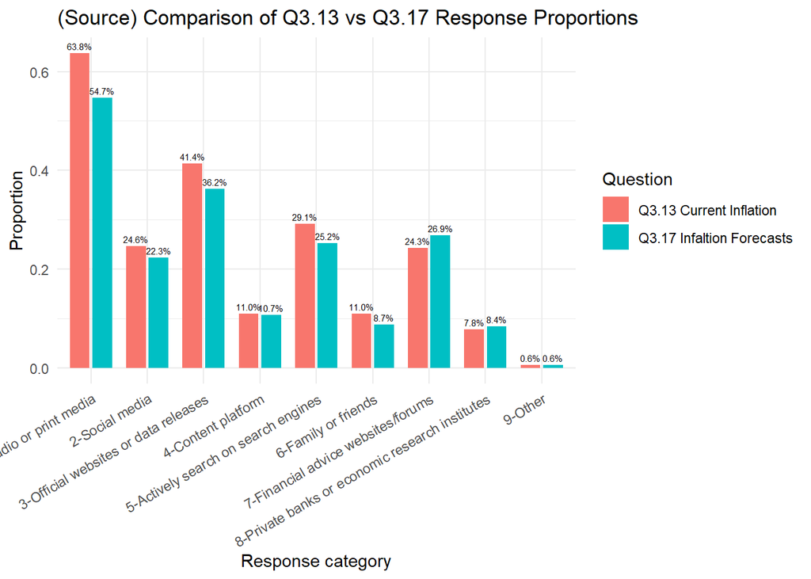

```r
q3_13_long <- q3_13_summary %>%
  rename(choice = `Q3.13_label`) %>%
  mutate(question = "Q3.13 Current Inflation")
q3_17_long <- q3_17_summary %>%
  rename(choice = `Q3.17_label`) %>%
  mutate(question = "Q3.17 Infaltion Forecasts")
# bind them together
q3_source <- bind_rows(q3_13_long, q3_17_long)
# plot
ggplot(q3_source, aes(x = choice, y = proportion, fill = question)) +
  geom_col(position = position_dodge(width = 0.8), width = 0.7) +
  geom_text(aes(label = scales::percent(proportion, accuracy = 0.1)),
            position = position_dodge(width = 0.8), vjust = -0.5,size = 2) +
  labs(
    title = "(Source) Comparison of Q3.13 vs Q3.17 Response Proportions",
    x     = "Response category",
    y     = "Proportion",
    fill  = "Question"
  ) +
  theme_minimal() +
  theme(
    axis.text.x = element_text(angle = 30, hjust = 1)
  )
```

Impact

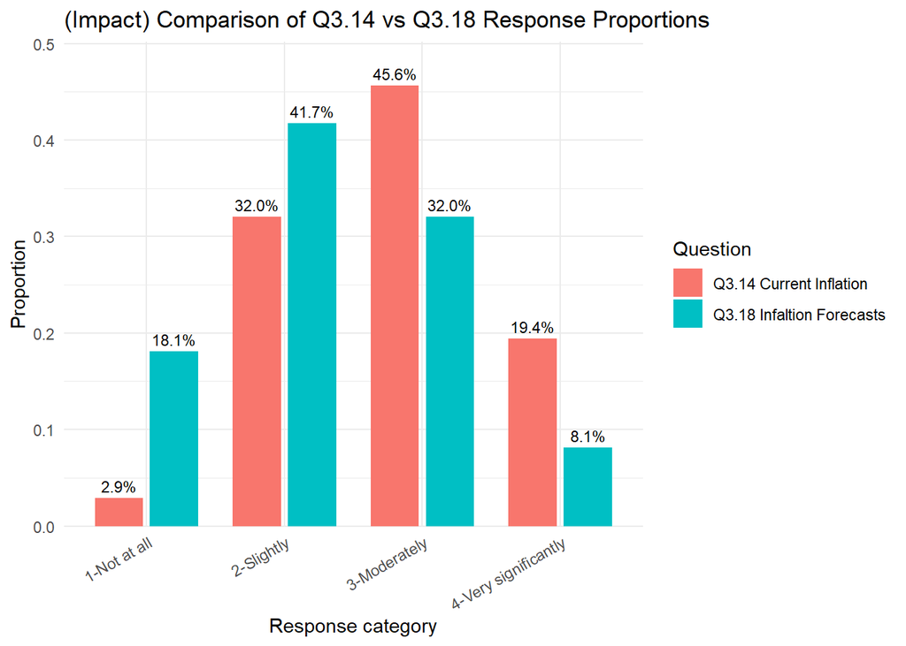

```r
q3_14_long <- q3_14_prop %>%
group_by(`Q3.14_label`) %>%
  rename(choice = `Q3.14_label`) %>%
  summarise(total_count = sum(Count), .groups = "drop") %>%
  mutate(proportion = total_count / sum(total_count),
         question = "Q3.14 Current Inflation")

q3_18_long <- q3_18_prop %>%
  group_by(`Q3.18_label`) %>%
  rename(choice = `Q3.18_label`) %>%
  summarise(total_count = sum(Count), .groups = "drop") %>%
  mutate(proportion = total_count / sum(total_count),
         question = "Q3.18 Infaltion Forecasts")
# bind them together
q3_impact <- bind_rows(q3_14_long, q3_18_long)

ggplot(q3_impact, aes(x = choice, y = proportion, fill = question)) +
  # facet_wrap(~ question) +
  geom_col(position = position_dodge(width = 0.8), width = 0.7) +
  geom_text(aes(label = scales::percent(proportion, accuracy = 0.1)),
        position = position_dodge(width = 0.8), vjust = -0.5,size =3) +
  scale_y_continuous(
    expand = expansion(mult = c(0, 0.1))
  ) +
  labs(
    title = "(Impact) Comparison of Q3.14 vs Q3.18 Response Proportions",
    x     = "Response category",
    y     = "Proportion",
    fill  = "Question"
  ) +
  theme_minimal() +
  theme(
    axis.text.x = element_text(angle = 30, hjust = 1)
  )
```

Response

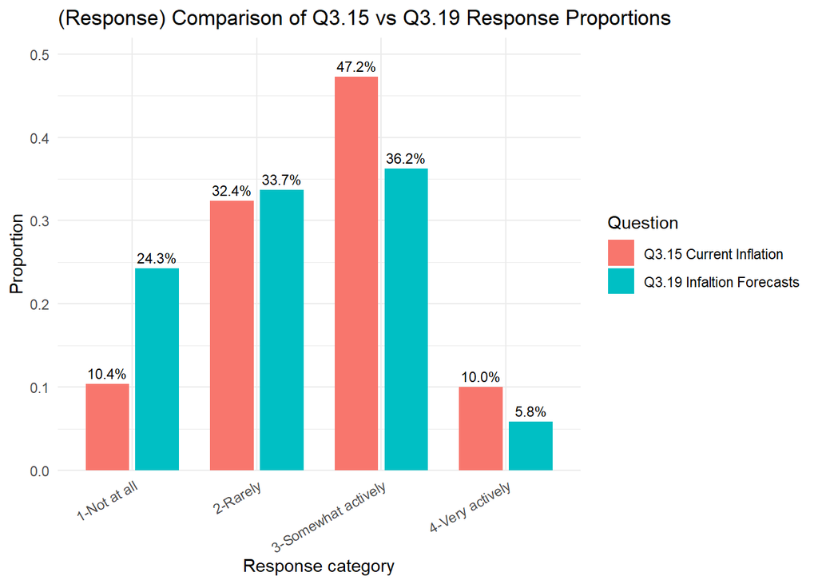

```r
q3_15_long <- q3_15_prop %>%
group_by(`Q3.15_label`) %>%
  rename(choice = `Q3.15_label`) %>%
  summarise(total_count = sum(Count), .groups = "drop") %>%
  mutate(proportion = total_count / sum(total_count),
         question = "Q3.15 Current Inflation")
q3_19_long <- q3_19_prop %>%
  group_by(`Q3.19_label`) %>%
  rename(choice = `Q3.19_label`) %>%
  summarise(total_count = sum(Count), .groups = "drop") %>%
  mutate(proportion = total_count / sum(total_count),
         question = "Q3.19 Infaltion Forecasts")
# bind them together
q3_response <- bind_rows(q3_15_long, q3_19_long)
ggplot(q3_response, aes(x = choice, y = proportion, fill = question)) +
  geom_col(position = position_dodge(width = 0.8), width = 0.7) +
  geom_text(aes(label = scales::percent(proportion, accuracy = 0.1)),
            position = position_dodge(width = 0.8), vjust = -0.5, size =3) +
  scale_y_continuous(
    expand = expansion(mult = c(0, 0.1))
  ) +
  labs(
    title = "(Response) Comparison of Q3.15 vs Q3.19 Response Proportions",
    x     = "Response category",
    y     = "Proportion",
    fill  = "Question"
  ) +
  theme_minimal() +
  theme(
    axis.text.x = element_text(angle = 30, hjust = 1)
  )
```

# Actual Survey Analysis

## Qxx.2 Graph Familarity

```r
# combine data from different groups
survey_q2 <- data.frame()
survey_q2_list <- list("Q4.2","Q6.2", "Q8.2", "Q10.2", "Q12.2")

for (i in seq_along(group_list)) {
  df <- group_list[[i]]
  col <- survey_q2_list[[i]]
  temp_table <- df[, c(col, "group")]
  names(temp_table) <- c("q2_value", "group")
  survey_q2 <- rbind(survey_q2, temp_table)
}

# recode the category
survey_q2 <- survey_q2 %>%
  mutate(q2_recode = case_when(
    q2_value %in% c("1", "2") ~ "N",
    q2_value %in% c("3", "4") ~ "Y"
  ))

survey_q2_contingency <- table(survey_q2$q2_recode, survey_q2$group)
# print the contingency table
print(survey_q2_contingency)
```

```
##
##     0-controlled 1-errorbar 2-shadedbar 3-fanchartslice 4-bellcurve
##   N           31         32          43              40          30
##   Y           31         27          18              26          31
```

```r
# Chi-squared test
chisq.test(survey_q2_contingency)
```

```
##
##  Pearson's Chi-squared test
##
## data:  survey_q2_contingency
## X-squared = 7.8234, df = 4, p-value = 0.09827
```

```r
# chisq_result <- chisq.test(survey_q2_contingency)
# chisq_result$stdres
# chisq_result$expected #(If many values are < 5, your Chi-squared test may be less reliable.)
# Post-hoc test for N --> no single pairwise difference is strong
# pairwise.prop.test(
#   x = survey_q2_contingency["N", ],
#   n = colSums(survey_q2_contingency),
#   p.adjust.method = "holm"
# )
```

Summary Table of proportion of yes and no

```r
yes_per <- survey_q2_contingency[2,]
no_per <- survey_q2_contingency[1,]
familarity_group_total <- colSums(survey_q2_contingency)
yes_prop <- yes_per/familarity_group_total
no_prop <- no_per/familarity_group_total
# convert to data frame
survey_q2_summary <-data.frame(yes_prop, no_prop)
```

Plot the graph

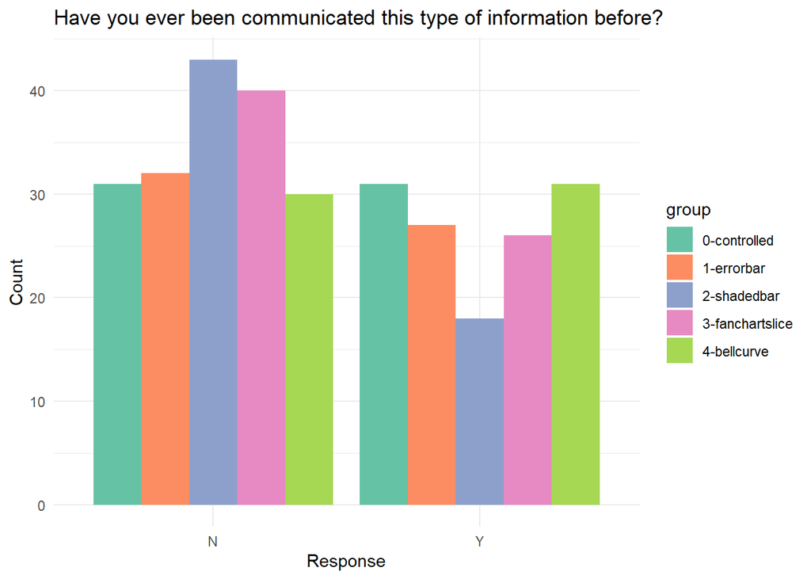

```r
ggplot(survey_q2, aes(x = q2_recode, fill = group)) +
  geom_bar(position = "dodge") +
  labs(title = "Have you ever been communicated this type of information before?",
       x = "Response",
       y = "Count") +
  scale_fill_brewer(palette = "Set2") +
  theme_minimal()
```

## Qxx.3 Prior Expectation

Does the inflation forecast information provided align with your expectations?  
Variable: categorical  
Method: Contingency Table + Chi-squared test  
**Result: Fail to reject the null hypothesis**

```r
# combine data from different groups
survey_q3 <- data.frame()
survey_q3_list <- list("Q4.3","Q6.3", "Q8.3", "Q10.3", "Q12.3")
for (i in seq_along(group_list)) {
  df <- group_list[[i]]
  col <- survey_q3_list[[i]]
  temp_table <- df[, c(col, "group")]
  names(temp_table) <- c("q3_value", "group")
  survey_q3 <- rbind(survey_q3, temp_table)
}

# Initial Check
summary(as.numeric(survey_q3$q3_value))
```

```
##    Min. 1st Qu.  Median    Mean 3rd Qu.    Max.
##   1.000   2.000   2.000   2.476   3.000   5.000
```

Test the differences between groups

```r
survey_q3_contingency <- table(survey_q3$q3_value, survey_q3$group)
# print the contingency table
print(survey_q3_contingency)
```

```
##
##     0-controlled 1-errorbar 2-shadedbar 3-fanchartslice 4-bellcurve
##   1            4          3           1               1           4
##   2           33         39          33              34          31
##   3           19         15          21              21          20
##   4            6          1           6              10           3
##   5            0          1           0               0           3
```

```r
# Chi-squared test
chisq.test(survey_q3_contingency)
```

```
##
##  Pearson's Chi-squared test
##
## data:  survey_q3_contingency
## X-squared = 22.933, df = 16, p-value = 0.1155
```

Plot prior expectation proportion bar plot across different groups

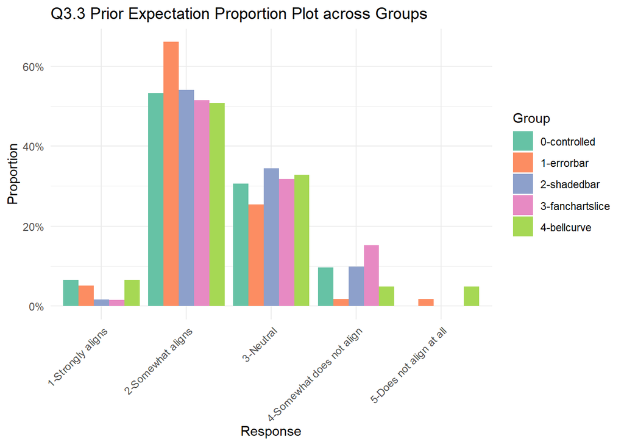

```r
survey_q3_prop  <- as.data.frame(survey_q3_contingency)
# rename columns
names(survey_q3_prop) <- c("Q3.3", "Group", "Count")
# add a labelled column
survey_q3_prop <- survey_q3_prop %>%
  mutate(Q3.3_label = case_when(
    Q3.3 == "1" ~ "1-Strongly aligns",
    Q3.3 == "2" ~ "2-Somewhat aligns",
    Q3.3 == "3" ~ "3-Neutral",
    Q3.3 == "4" ~ "4-Somewhat does not align",
    Q3.3 == "5" ~ "5-Does not align at all",
  ))
# calculate proportions within each group
survey_q3_prop <- survey_q3_prop %>%
  group_by(Group) %>%
  mutate(Proportion = Count / sum(Count))
ggplot(survey_q3_prop, aes(x = as.factor(`Q3.3_label`), y = Proportion, fill = Group)) + geom_col(position = "dodge") +
  labs(
    title = "Q3.3 Prior Expectation Proportion Plot across Groups",
    x = "Response",
    y = "Proportion"
  ) +
   scale_fill_brewer(palette = "Set2")+
  scale_y_continuous(labels = scales::percent_format(accuracy = 1)) +
  theme_minimal()+
  theme(axis.text.x = element_text(angle = 45, hjust = 1))
```

Plot pie chart including all participants

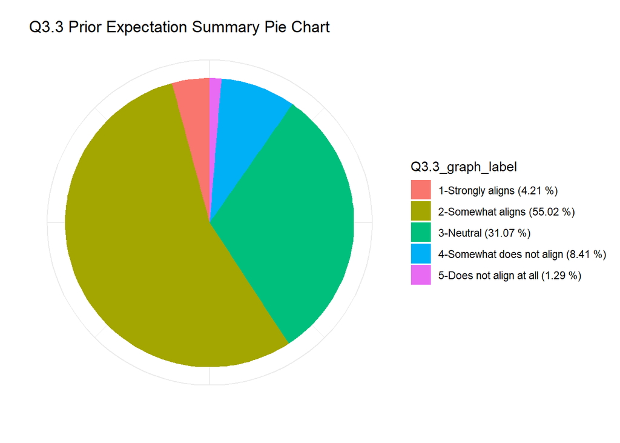

```r
survey_q3_summary <- survey_q3_prop %>%
  group_by(`Q3.3_label`) %>%
  summarise(total_count = sum(Count), .groups = "drop") %>%
  mutate(proportion = total_count / sum(total_count),
         `Q3.3_graph_label` = paste0(`Q3.3_label`, " (", round(proportion * 100, 2), " %)"))
ggplot(survey_q3_summary, aes(x = "",y = proportion, fill = `Q3.3_graph_label`)) +
  geom_col(width = 1) +
  coord_polar(theta = "y") +
  labs(title = "Q3.3 Prior Expectation Summary Pie Chart",
       x = "",
       y = "") +
  theme_minimal() +
  theme(axis.text.x = element_blank())
```

## Qxx.4 Confliction with Prior Expectation How does the inflation forecast conflict with your expectations?  
Variable: categorical  
Method: calculate total number of people who think the forecast is not aligned with their expectation  
**Result: Among people who think the forecast is not aligned with their expectation, 90% percent of respondents thinks the forecast is lower than what they expected.**

```r
# Check the number of people answered this question
n_not_align <- sum(survey_q3_summary$total_count[4:5])
# Combine data from different groups
survey_q4 <- data.frame()
survey_q4_list <- list("Q4.4","Q6.4", "Q8.4", "Q10.4", "Q12.4")
for (i in seq_along(group_list)) {
  df <- group_list[[i]]
  col <- survey_q4_list[[i]]
  temp_table <- df[, c(col, "group")]
  names(temp_table) <- c("q4_value", "group")
  survey_q4 <- rbind(survey_q4, temp_table)
}
survey_q4 <- survey_q4[!is.na(survey_q4$q4_value), ]
survey_q4_contingency <- table(survey_q4$q4_value, survey_q4$group)
# print the contingency table
print(survey_q4_contingency)
```

```
##
##     0-controlled 1-errorbar 2-shadedbar 3-fanchartslice 4-bellcurve
##   1            1          0           2               0           0
##   2            5          2           4              10           6
```

Plot confliction with prior expectation proportion bar plot across different groups

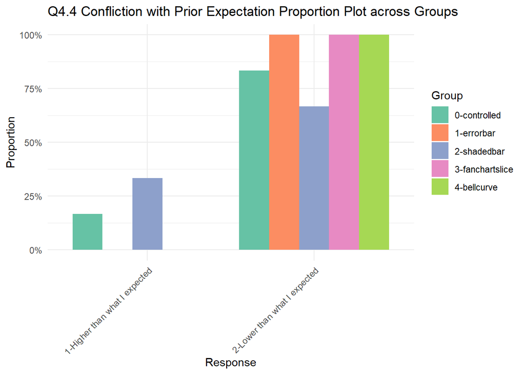

```r
survey_q4_prop  <- as.data.frame(survey_q4_contingency)
# rename columns
names(survey_q4_prop) <- c("Q4.4", "Group", "Count")
# add a labelled column
survey_q4_prop <- survey_q4_prop %>%
  mutate(Q4.4_label = case_when(
    Q4.4 == "1" ~ "1-Higher than what I expected",
    Q4.4 == "2" ~ "2-Lower than what I expected"
  ))
# calculate proportions within each group
survey_q4_prop <- survey_q4_prop %>%
  group_by(Group) %>%
  mutate(Proportion = Count / sum(Count))
ggplot(survey_q4_prop, aes(x = as.factor(`Q4.4_label`), y = Proportion, fill = Group)) + geom_col(position = "dodge") +
  labs(
    title = "Q4.4 Confliction with Prior Expectation Proportion Plot across Groups",
    x = "Response",
    y = "Proportion"
  ) +
   scale_fill_brewer(palette = "Set2")+
  scale_y_continuous(labels = scales::percent_format(accuracy = 1)) +
  theme_minimal()+
  theme(axis.text.x = element_text(angle = 45, hjust = 1))
```

Plot pie chart including all participants

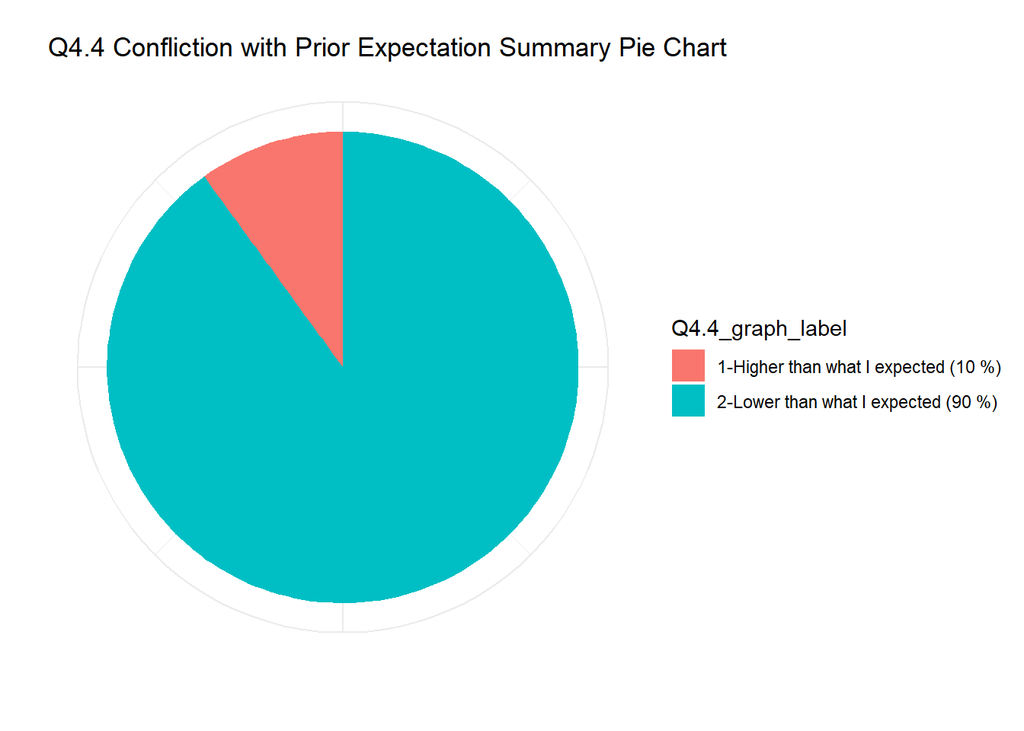

```r
survey_q4_summary <- survey_q4_prop %>%
  group_by(`Q4.4_label`) %>%
  summarise(total_count = sum(Count), .groups = "drop") %>%
  mutate(proportion = total_count / sum(total_count),
         `Q4.4_graph_label` = paste0(`Q4.4_label`, " (", round(proportion * 100, 2), " %)"))
ggplot(survey_q4_summary, aes(x = "",y = proportion, fill = `Q4.4_graph_label`)) +
  geom_col(width = 1) +
  coord_polar(theta = "y") +
  labs(title = "Q4.4 Confliction with Prior Expectation Summary Pie Chart",
       x = "",
       y = "") +
  theme_minimal() +
  theme(axis.text.x = element_blank())
```

## Qxx.6 Probability of exactly 2.6% what do you think is the probability of inflation being exactly 2.6%?  
Definitive Correct Answer  
*descending order*  
Variable: categorical  
Method: contingency table & proportion test  
**Result: There is no statistical difference in terms of correctly answering the probability of inflation being exactly 2.6%.**

```r
# combine data from different groups
survey_q6 <- data.frame()
survey_q6_list <- list("Q4.6","Q6.6", "Q8.6", "Q10.6", "Q12.6")
for (i in seq_along(group_list)) {
  df <- group_list[[i]]
  col <- survey_q6_list[[i]]
  temp_table <- df[, c(col, "group")]
  names(temp_table) <- c("q6_value", "group")
  survey_q6 <- rbind(survey_q6, temp_table)
}
survey_q6$q6_value <- as.numeric(survey_q6$q6_value)

survey_q6_contingency <- table(survey_q6$q6_value, survey_q6$group)
print(survey_q6_contingency)
```

```
##
##     0-controlled 1-errorbar 2-shadedbar 3-fanchartslice 4-bellcurve
##   1            0          0           1               0           0
##   2            4          5          10               8           5
##   3           18         12           3               6           5
##   4            5          4           3               3           2
##   5           20          5          20              22          25
##   6            7         17          10              13          12
##   7            8         16          14              14          12
```

```r
# whether one proportion differs across groups
less_than_1_per <- survey_q6_contingency[7,]
survey_q6_group_total <- colSums(survey_q6_contingency)
prop.test(less_than_1_per, survey_q6_group_total)
```

```
##
##  5-sample test for equality of proportions without continuity correction
##
## data:  less_than_1_per out of survey_q6_group_total
## X-squared = 4.0132, df = 4, p-value = 0.4042
## alternative hypothesis: two.sided
## sample estimates:
##    prop 1    prop 2    prop 3    prop 4    prop 5
## 0.1290323 0.2711864 0.2295082 0.2121212 0.1967213
```

Plot probability of exactly 2.6% proportion bar plot across different groups

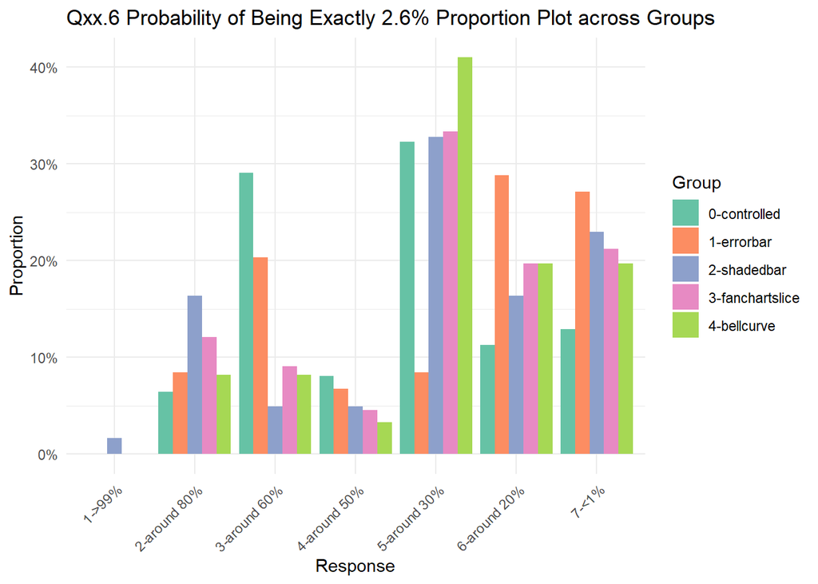

```r
survey_q6_prop  <- as.data.frame(survey_q6_contingency)
# rename columns
names(survey_q6_prop) <- c("Qxx.6", "Group", "Count")
# add a labelled column
survey_q6_prop <- survey_q6_prop %>%
  mutate(Qxx.6_label = case_when(
    Qxx.6 == "1" ~ "1->99%",
    Qxx.6 == "2" ~ "2-around 80%",
    Qxx.6 == "3" ~ "3-around 60%",
    Qxx.6 == "4" ~ "4-around 50%",
    Qxx.6 == "5" ~ "5-around 30%",
    Qxx.6 == "6" ~ "6-around 20%",
    Qxx.6 == "7" ~ "7-<1%"
  ))
# calculate proportions within each group
survey_q6_prop <- survey_q6_prop %>%
  group_by(Group) %>%
  mutate(Proportion = Count / sum(Count))
ggplot(survey_q6_prop, aes(x = as.factor(`Qxx.6_label`), y = Proportion, fill = Group)) + geom_col(position = "dodge") +
  # facet_wrap(~Group)+
  labs(
    title = "Qxx.6 Probability of Being Exactly 2.6% Proportion Plot across Groups",
    x = "Response",
    y = "Proportion"
  ) +
   scale_fill_brewer(palette = "Set2")+
  scale_y_continuous(labels = scales::percent_format(accuracy = 1)) +
  theme_minimal()+
  theme(axis.text.x = element_text(angle = 45, hjust = 1))
```

Plot the histogram including all participants

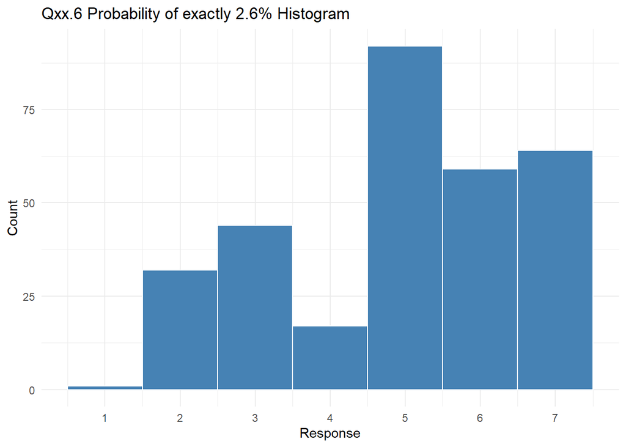

```r
# histogram including all participants
ggplot(survey_q6, aes(x = q6_value)) +
  geom_histogram(binwidth = 1, fill = "steelblue", color = "white") +
  labs(title = "Qxx.6 Probability of exactly 2.6% Histogram",
       x = "Response",
       y = "Count") +
  scale_x_continuous(breaks = seq(0, max(survey_q6$q6_value, na.rm = TRUE), by = 1)) +
  theme_minimal()
```

Plot pie chart including all participants

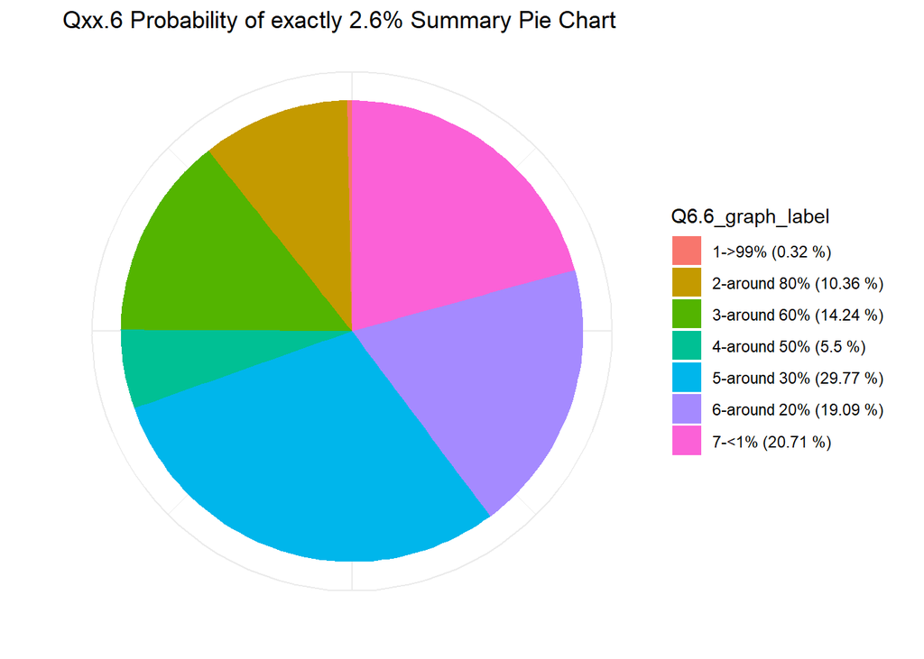

```r
survey_q6_summary <- survey_q6_prop %>%
  group_by(`Qxx.6_label`) %>%
  summarise(total_count = sum(Count), .groups = "drop") %>%
  mutate(proportion = total_count / sum(total_count),
         `Q6.6_graph_label` = paste0(`Qxx.6_label`, " (", round(proportion * 100, 2), " %)"))
ggplot(survey_q6_summary, aes(x = "",y = proportion, fill = `Q6.6_graph_label`)) +
  geom_col(width = 1) +
  coord_polar(theta = "y") +
  labs(title = "Qxx.6 Probability of exactly 2.6% Summary Pie Chart",
       x = "",
       y = "") +
  theme_minimal() +
  theme(axis.text.x = element_blank())
```

## ! Qxx.7 Probability of between 1.9% and 3.3%

what do you think is the probability of inflation being between 1.9% and 3.3%?  
Definitive Correct Answer  
*descending order*  
Method: contingency table & proportion test  
**Result: There is statistical difference in control group in terms of the proportion of the correct answer of how people think the probability of inflation being between 1.9% and 3.3% is.**

```r
# combine data from different groups
survey_q7 <- data.frame()
survey_q7_list <- list("Q4.7","Q6.7", "Q8.7", "Q10.7", "Q12.7")
for (i in seq_along(group_list)) {
  df <- group_list[[i]]
  col <- survey_q7_list[[i]]
  temp_table <- df[, c(col, "group")]
  names(temp_table) <- c("q7_value", "group")
  survey_q7 <- rbind(survey_q7, temp_table)
}
survey_q7$q7_value <- as.numeric(survey_q7$q7_value)
```

Test the proportion of correct answer

```r
survey_q7_contingency <- table(survey_q7$q7_value, survey_q7$group)
# print the contingency table
print(survey_q7_contingency)
```

```
##
##     0-controlled 1-errorbar 2-shadedbar 3-fanchartslice 4-bellcurve
##   1           10          0           0               3           1
##   2           23          7          11               9           9
##   3           17         18          11              14           7
##   4            9         13           7               8          10
##   5            3         18          27              25          29
##   6            0          3           5               7           4
##   7            0          0           0               0           1
```

```r
# correct answer
survey_q7_correct <- survey_q7_contingency[5,]
survey_q7_group_total <- colSums(survey_q7_contingency)
prop.test(survey_q7_correct, survey_q7_group_total)
```

```
##
##  5-sample test for equality of proportions without continuity correction
##
## data:  survey_q7_correct out of survey_q7_group_total
## X-squared = 32.443, df = 4, p-value = 1.553e-06
## alternative hypothesis: two.sided
## sample estimates:
##    prop 1    prop 2    prop 3    prop 4    prop 5
## 0.0483871 0.3050847 0.4426230 0.3787879 0.4754098
```

```r
# pairwise proportion test
pairwise.prop.test(
  x = survey_q7_contingency[5, ],
  n = colSums(survey_q7_contingency),
  p.adjust.method = "bonferroni" # or "holm", "BH"
)
```

```
##
##  Pairwise comparisons using Pairwise comparison of proportions
##
## data:  survey_q7_contingency[5, ] out of colSums(survey_q7_contingency)
##
##                 0-controlled 1-errorbar 2-shadedbar 3-fanchartslice
## 1-errorbar      0.00489      -          -           -
## 2-shadedbar     1.1e-05      1.00000    -           -
## 3-fanchartslice 0.00017      1.00000    1.00000     -
## 4-bellcurve     2.1e-06      0.84724    1.00000     1.00000
##
## P value adjustment method: bonferroni
```

Plot probability of between 1.9% and 3.3% proportion bar plot across different groups

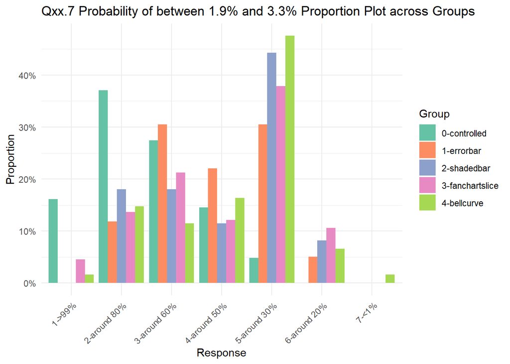

```r
survey_q7_prop  <- as.data.frame(survey_q7_contingency)
# rename columns
names(survey_q7_prop) <- c("Qxx.7", "Group", "Count")
# add a labelled column
survey_q7_prop <- survey_q7_prop %>%
  mutate(Qxx.7_label = case_when(
    Qxx.7 == "1" ~ "1->99%",
    Qxx.7 == "2" ~ "2-around 80%",
    Qxx.7 == "3" ~ "3-around 60%",
    Qxx.7 == "4" ~ "4-around 50%",
    Qxx.7 == "5" ~ "5-around 30%",
    Qxx.7 == "6" ~ "6-around 20%",
    Qxx.7 == "7" ~ "7-<1%"
  ))
# calculate proportions within each group
survey_q7_prop <- survey_q7_prop %>%
  group_by(Group) %>%
  mutate(Proportion = Count / sum(Count))
ggplot(survey_q7_prop, aes(x = as.factor(`Qxx.7_label`), y = Proportion, fill = Group)) + geom_col(position = "dodge") +
  # facet_wrap(~Group)+
  labs(
    title = "Qxx.7 Probability of between 1.9% and 3.3% Proportion Plot across Groups",
    x = "Response",
    y = "Proportion"
  ) +
   scale_fill_brewer(palette = "Set2")+
  scale_y_continuous(labels = scales::percent_format(accuracy = 1)) +
  theme_minimal()+
  theme(axis.text.x = element_text(angle = 45, hjust = 1))
```

Plot the histogram including all participants

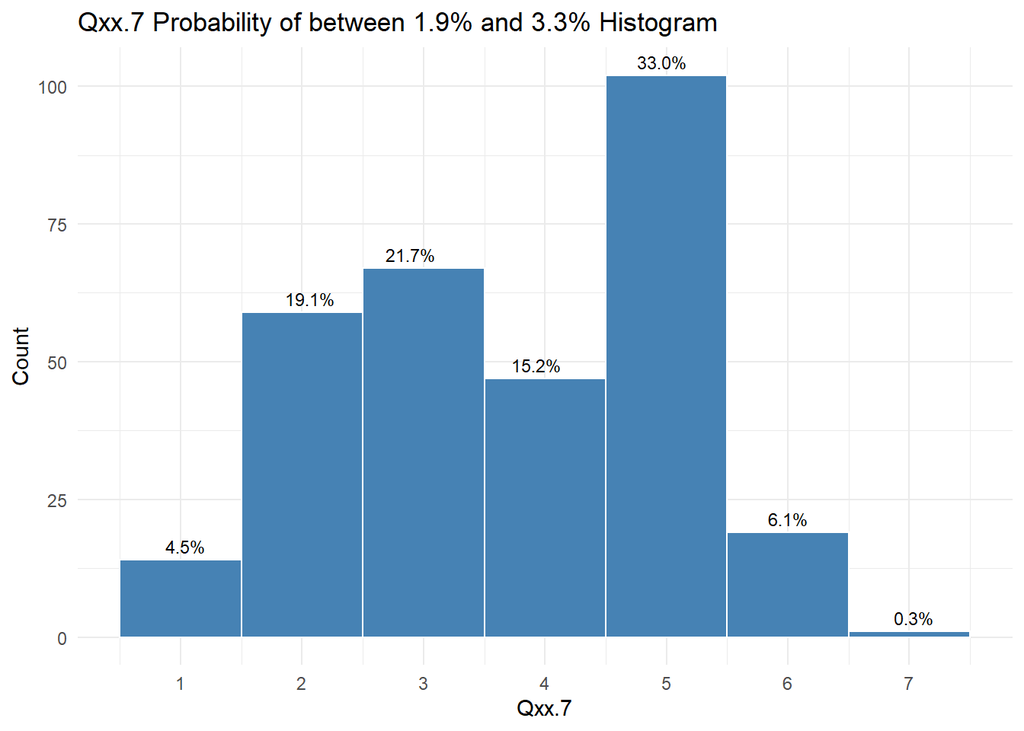

```r
# histogram including all participants
ggplot(survey_q7, aes(x = q7_value)) +
  geom_histogram(binwidth = 1, fill = "steelblue", color = "white") +
  geom_text(     stat = "bin",
    aes(
      label = after_stat(
        ifelse(
          count == 0,
          "",
          scales::percent(count / total_respondents, accuracy = 0.1)
        )
      )
    ), vjust = -0.5, size = 3) +
  # facet_wrap(~ group) +
  labs(title = "Qxx.7 Probability of between 1.9% and 3.3% Histogram",
       x = "Qxx.7",
       y = "Count") +
  scale_x_continuous(breaks = seq(0, max(survey_q7$q7_value, na.rm = TRUE), by = 1)) +
  theme_minimal()
```

## Qxx.8 Probability of between 3.3% and 5.6%

what do you think is the probability of inflation being between 3.3% and 5.6%?  
Definitive Correct Answer  
*descending order*  
Method: contingency table & proportion test  
**Result: The control group and the error bar group has shown statistical difference.**

```r
# combine data from different groups
survey_q8 <- data.frame()
survey_q8_list <- list("Q4.8","Q6.8", "Q8.8", "Q10.8", "Q12.8")
for (i in seq_along(group_list)) {
  df <- group_list[[i]]
  col <- survey_q8_list[[i]]
  temp_table <- df[, c(col, "group")]
  names(temp_table) <- c("q8_value", "group")
  survey_q8 <- rbind(survey_q8, temp_table)
}
survey_q8$q8_value <- as.numeric(survey_q8$q8_value)
```

contingency table

```r
survey_q8_contingency <- table(survey_q8$q8_value, survey_q8$group)
# print the contingency table
print(survey_q8_contingency)
```

```
##
##     0-controlled 1-errorbar 2-shadedbar 3-fanchartslice 4-bellcurve
##   1            1          0           1               1           1
##   2            3          2           3               2           7
##   3           13          4           5              10           5
##   4            5          5           9               6           2
##   5           14         34          29              23          28
##   6           18         13          11              22          12
##   7            8          1           3               2           6
```

```r
# correct answer
survey_q8_correct <- survey_q8_contingency[5,]
survey_q8_group_total <- colSums(survey_q8_contingency)
prop.test(survey_q8_correct, survey_q8_group_total)
```

```
##
##  5-sample test for equality of proportions without continuity correction
##
## data:  survey_q8_correct out of survey_q8_group_total
## X-squared = 18.077, df = 4, p-value = 0.001192
## alternative hypothesis: two.sided
## sample estimates:
##    prop 1    prop 2    prop 3    prop 4    prop 5
## 0.2258065 0.5762712 0.4754098 0.3484848 0.4590164
```

```r
# pairwise proportion test
pairwise.prop.test(
  x = survey_q8_contingency[5, ],
  n = colSums(survey_q8_contingency),
  p.adjust.method = "bonferroni" # or "holm", "BH"
)
```

```
##
##  Pairwise comparisons using Pairwise comparison of proportions
##
## data:  survey_q8_contingency[5, ] out of colSums(survey_q8_contingency)
##
##                 0-controlled 1-errorbar 2-shadedbar 3-fanchartslice
## 1-errorbar      0.0017       -          -           -
## 2-shadedbar     0.0666       1.0000     -           -
## 3-fanchartslice 1.0000       0.1766     1.0000      -
## 4-bellcurve     0.1118       1.0000     1.0000      1.0000
##
## P value adjustment method: bonferroni
```

Plot probability of between 3.3% and 5.6% proportion bar plot across different groups

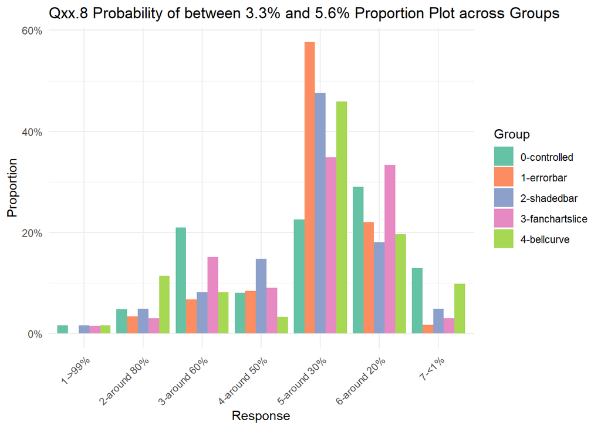

```r
survey_q8_prop  <- as.data.frame(survey_q8_contingency)
# rename columns
names(survey_q8_prop) <- c("Qxx.8", "Group", "Count")
# add a labelled column
survey_q8_prop <- survey_q8_prop %>%
  mutate(Qxx.8_label = case_when(
    Qxx.8 == "1" ~ "1->99%",
    Qxx.8 == "2" ~ "2-around 80%",
    Qxx.8 == "3" ~ "3-around 60%",
    Qxx.8 == "4" ~ "4-around 50%",
    Qxx.8 == "5" ~ "5-around 30%",
    Qxx.8 == "6" ~ "6-around 20%",
    Qxx.8 == "7" ~ "7-<1%"
  ))
# calculate proportions within each group
survey_q8_prop <- survey_q8_prop %>%
  group_by(Group) %>%
  mutate(Proportion = Count / sum(Count))
ggplot(survey_q8_prop, aes(x = as.factor(`Qxx.8_label`), y = Proportion, fill = Group)) + geom_col(position = "dodge") +
  # facet_wrap(~Group)+
  labs(
    title = "Qxx.8 Probability of between 3.3% and 5.6% Proportion Plot across Groups",
    x = "Response",
    y = "Proportion"
  ) +
   scale_fill_brewer(palette = "Set2")+
  scale_y_continuous(labels = scales::percent_format(accuracy = 1)) +
  theme_minimal()+
  theme(axis.text.x = element_text(angle = 45, hjust = 1))
```

Plot the histogram including all participants

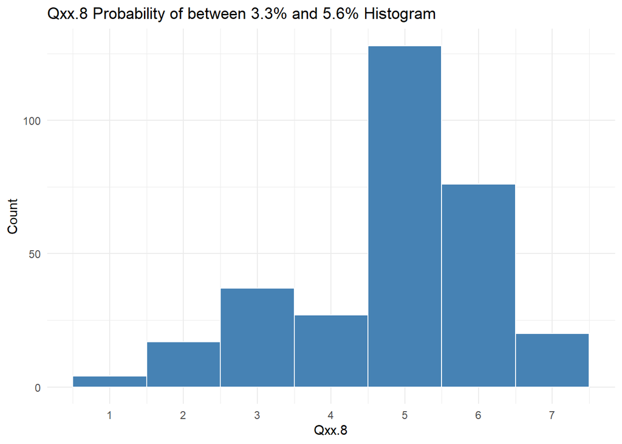

```r
# histogram including all participants
ggplot(survey_q8, aes(x = q8_value)) +
  geom_histogram(binwidth = 1, fill = "steelblue", color = "white") +
  # facet_wrap(~ group) +
  labs(title = "Qxx.8 Probability of between 3.3% and 5.6% Histogram",
       x = "Qxx.8",
       y = "Count") +
  scale_x_continuous(breaks = seq(0, max(survey_q8$q8_value, na.rm = TRUE), by = 1)) +
  theme_minimal()
```

## ! Qxx.10 Probability of ending outside the range Based on the inflation forecast provided, what do you think is the probability of inflation ending up outside of the range from -0.4% to 5.6%?  
Definitive Correct Answer (varied between group)  
*descending order*  
Variable: categorical  
Method: calculate the proportion for each group + proportion test  
**Result: Control group perform significant worse than other groups.**

```r
survey_q10 <- data.frame(
  group   = character(0),
  correct = integer(0),
  total   = integer(0),
  prop    = numeric(0)
)
survey_q10_list <- list("Q4.10","Q6.10", "Q8.10", "Q10.10", "Q12.10")
survey_q10_correct <-c(8,12,14,14,14) # 10%, 40%. 10%, 10%, 10%

for (i in seq_along(group_list)) {
  df <- group_list[[i]]
  col <- survey_q10_list[[i]]
  q10_correct <- survey_q10_correct[i]

  # count total number of people in each group
  total_count <- nrow(df)
  # count number of people who answered correctly
  correct_count <- sum(df[, col] == q10_correct, na.rm = TRUE)
  # compute the proportion
  prop <- correct_count / total_count
  # capture the group name
  grp_label <- names(group_list[i])
  # row-bind into survey_q10
  survey_q10 <- rbind(survey_q10, data.frame(
    group = grp_label,
    correct = correct_count,
    total = total_count,
    prop = prop))
}

# proportion test --> There is significant difference
prop.test(x = survey_q10$correct,
          n = survey_q10$total)
```

```
##
##  5-sample test for equality of proportions without continuity correction
##
## data:  survey_q10$correct out of survey_q10$total
## X-squared = 36.59, df = 4, p-value = 2.187e-07
## alternative hypothesis: two.sided
## sample estimates:
##    prop 1    prop 2    prop 3    prop 4    prop 5
## 0.1612903 0.5762712 0.4426230 0.4696970 0.6721311
```

```r
# pairwise proportion test
pairwise.prop.test(
  x = setNames(survey_q10$correct, survey_q10$group),
  n = setNames(survey_q10$total,   survey_q10$group),
  p.adjust.method = "bonferroni" # or "holm", "BH"
)
```

```
##
##  Pairwise comparisons using Pairwise comparison of proportions
##
## data:  setNames(survey_q10$correct, survey_q10$group) out of setNames(survey_q10$total, survey_q10$group)
##
##               controlled errorbar shadedbar fanchartslice
## errorbar      5.3e-05    -        -         -
## shadedbar     0.0135     1.0000   -         -
## fanchartslice 0.0039     1.0000   1.0000    -
## bellcurve     2.6e-07    1.0000   0.1781    0.3392
##
## P value adjustment method: bonferroni
```

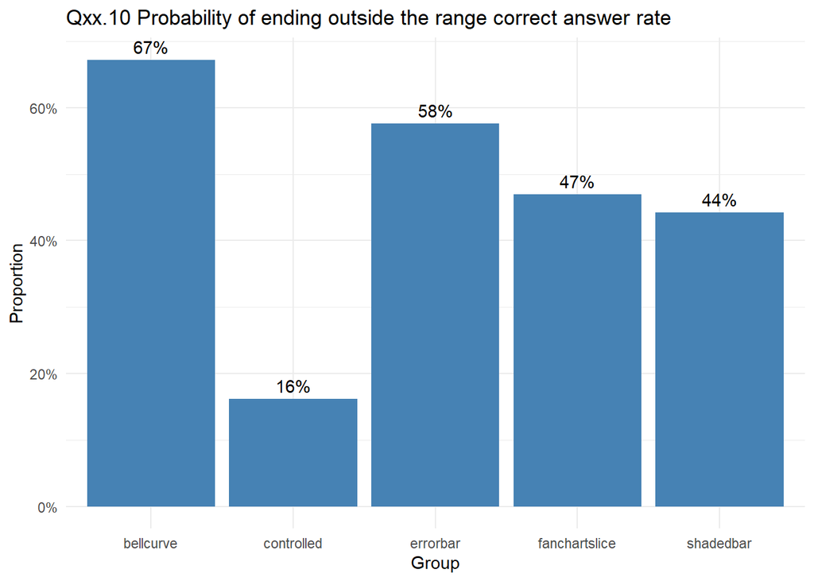

```r
ggplot(survey_q10, aes(x = group, y = prop)) +
  geom_bar(stat = "identity", fill = "steelblue") +
  geom_text(aes(label = scales::percent(prop, accuracy = 1)), vjust = -0.5) +
  labs(title = "Qxx.10 Probability of ending outside the range correct answer rate",
       x = "Group",
       y = "Proportion") +
  scale_y_continuous(labels = scales::percent_format(accuracy = 1)) +
  theme_minimal()
```

Plot distribution for each individual group (change the group and question number manually)

[figure not shown]

```r
ggplot(bell_curve, aes(x = as.numeric(as.character(Q12.10)))) +
  geom_histogram(binwidth = 1, fill = "steelblue", color = "white") +
  scale_y_continuous(
    limits = c(0, 50),        # force y from 0 up to 60
    breaks = seq(0, 50, by=10) # ticks at 0, 10, 20, …, 60
  ) +
  geom_text(aes(label = ..count..), stat = "count", vjust = -0.5) +
  labs(
    title = "Controlled Group: Distribution of Q4.10 Responses",
    x     = "Q4.10 (numeric)",
    y     = "Count"
  ) +
  theme_minimal()
```

```r
# combine data from different groups
survey_q11 <- data.frame()
survey_q11_list <- list("Q4.11","Q6.11", "Q8.11", "Q10.11", "Q12.11")
for (i in seq_along(group_list)) {
  df <- group_list[[i]]
  col <- survey_q11_list[[i]]
  temp_table <- df[, c(col, "group")]
  names(temp_table) <- c("q11_value", "group")
  survey_q11 <- rbind(survey_q11, temp_table)
}
survey_q11$q11_value <- as.numeric(survey_q11$q11_value)
```

Test the proportion of correct answer

```r
survey_q11_contingency <- table(survey_q11$q11_value, survey_q11$group)
# print the contingency table
print(survey_q11_contingency)
```

```
##
##     0-controlled 1-errorbar 2-shadedbar 3-fanchartslice 4-bellcurve
##   1            1          4           1               0           4
##   2           13         12           9              10           9
##   3           13         21          24              24          29
##   4           33         15          24              30          16
##   5            2          7           3               2           3
```

```r
survey_q11_correct <- survey_q11_contingency[3,]
survey_q11_group_total <- colSums(survey_q11_contingency)
prop.test(survey_q11_correct, survey_q11_group_total)
```

```
##
##  5-sample test for equality of proportions without continuity correction
##
## data:  survey_q11_correct out of survey_q11_group_total
## X-squared = 9.9199, df = 4, p-value = 0.0418
## alternative hypothesis: two.sided
## sample estimates:
##    prop 1    prop 2    prop 3    prop 4    prop 5
## 0.2096774 0.3559322 0.3934426 0.3636364 0.4754098
```

Post-hoc test

```r
pairwise.prop.test(
  x = survey_q11_contingency[3, ],
  n = colSums(survey_q11_contingency),
  p.adjust.method = "bonferroni" # or "holm", "BH"
)
```

```
##
##  Pairwise comparisons using Pairwise comparison of proportions
##
## data:  survey_q11_contingency[3, ] out of colSums(survey_q11_contingency)
##
##                 0-controlled 1-errorbar 2-shadedbar 3-fanchartslice
## 1-errorbar      1.000        -          -           -
## 2-shadedbar     0.428        1.000      -           -
## 3-fanchartslice 0.845        1.000      1.000       -
## 4-bellcurve     0.035        1.000      1.000       1.000
##
## P value adjustment method: bonferroni
```

Plot probability of higher than 6% proportion bar plot across different groups

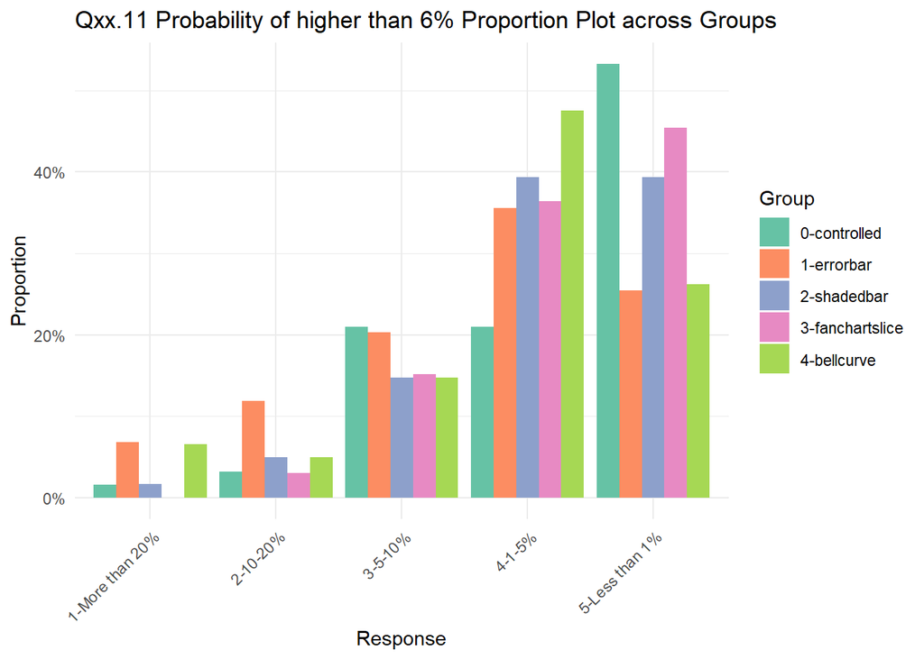

```r
survey_q11_prop  <- as.data.frame(survey_q11_contingency)
# rename columns
names(survey_q11_prop) <- c("Qxx.11", "Group", "Count")
# add a labelled column
survey_q11_prop <- survey_q11_prop %>%
  mutate(Qxx.11_label = case_when(
    Qxx.11 == "1" ~ "1-More than 20%",
    Qxx.11 == "2" ~ "3-5-10%",
    Qxx.11 == "3" ~ "4-1-5%",
    Qxx.11 == "4" ~ "5-Less than 1%",
    Qxx.11 == "5" ~ "2-10-20%"
  ))
# calculate proportions within each group
survey_q11_prop <- survey_q11_prop %>%
  group_by(Group) %>%
  mutate(Proportion = Count / sum(Count))
ggplot(survey_q11_prop, aes(x = as.factor(`Qxx.11_label`), y = Proportion, fill = Group)) + geom_col(position = "dodge") +
  # facet_wrap(~Group)+
  labs(
    title = "Qxx.11 Probability of higher than 6% Proportion Plot across Groups",
    x = "Response",
    y = "Proportion"
  ) +
   scale_fill_brewer(palette = "Set2")+
  scale_y_continuous(labels = scales::percent_format(accuracy = 1)) +
  theme_minimal()+
  theme(axis.text.x = element_text(angle = 45, hjust = 1))
```

Plot the histogram including all participants

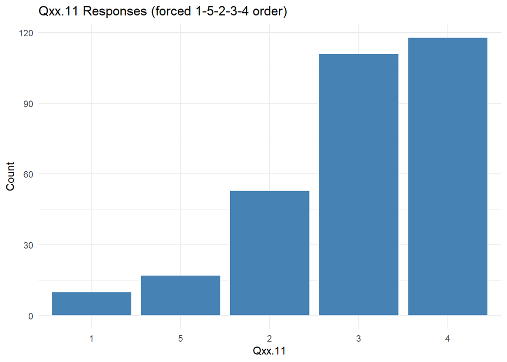

```r
# force order for graph
survey_q11 <- survey_q11 %>%
  mutate(
    q11_value_re = factor(
      q11_value,
      levels = c(1, 5, 2, 3, 4)
    )
  )
# histogram including all participants
ggplot(survey_q11, aes(x = q11_value_re)) +
  geom_bar(fill = "steelblue", color = "white") +
  labs(
    title = "Qxx.11 Responses (forced 1-5-2-3-4 order)",
    x     = "Qxx.11",
    y     = "Count"
  ) +
  theme_minimal()
```

```r
# combine data from different groups
survey_q12 <- data.frame()
survey_q12_list <- list("Q4.12","Q6.12", "Q8.12", "Q10.12", "Q12.12")
for (i in seq_along(group_list)) {
  df <- group_list[[i]]
  col <- survey_q12_list[[i]]
  temp_table <- df[, c(col, "group")]
  names(temp_table) <- c("q12_value", "group")
  survey_q12 <- rbind(survey_q12, temp_table)
}
survey_q12$q12_value <- as.numeric(survey_q12$q12_value)
```

Test the proportion of correct answer

```r
survey_q12_contingency <- table(survey_q12$q12_value, survey_q12$group)
# print the contingency table
print(survey_q12_contingency)
```

```
##
##     0-controlled 1-errorbar 2-shadedbar 3-fanchartslice 4-bellcurve
##   1            3          3           2               5           4
##   2           15         14          19              12          13
##   3           19         18          26              29          22
##   4           11          7          11              12          13
##   5           14         17           3               8           9
```

```r
survey_q12_correct <- survey_q12_contingency[2,]
survey_q12_group_total <- colSums(survey_q12_contingency)
prop.test(survey_q12_correct, survey_q12_group_total)
```

```
##
##  5-sample test for equality of proportions without continuity correction
##
## data:  survey_q12_correct out of survey_q12_group_total
## X-squared = 3.1893, df = 4, p-value = 0.5267
## alternative hypothesis: two.sided
## sample estimates:
##    prop 1    prop 2    prop 3    prop 4    prop 5
## 0.2419355 0.2372881 0.3114754 0.1818182 0.2131148
```

Plot probability of higher than 3% proportion bar plot across different groups

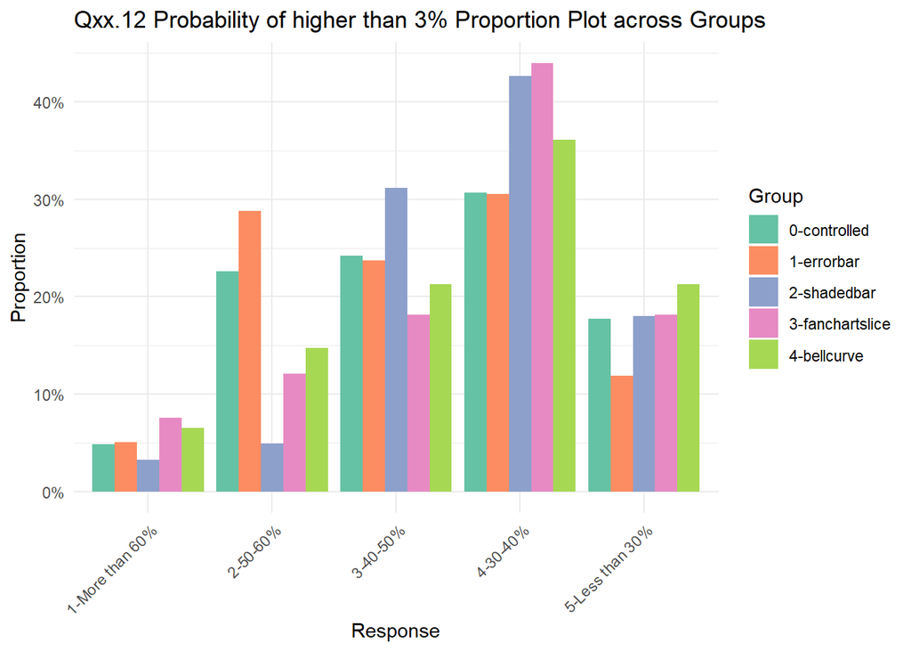

```r
survey_q12_prop  <- as.data.frame(survey_q12_contingency)
# rename columns
names(survey_q12_prop) <- c("Qxx.12", "Group", "Count")
# add a labelled column
survey_q12_prop <- survey_q12_prop %>%
  mutate(Qxx.12_label = case_when(
    Qxx.12 == "1" ~ "1-More than 60%",
    Qxx.12 == "2" ~ "3-40-50%",
    Qxx.12 == "3" ~ "4-30-40%",
    Qxx.12 == "4" ~ "5-Less than 30%",
    Qxx.12 == "5" ~ "2-50-60%"
  ))
# calculate proportions within each group
survey_q12_prop <- survey_q12_prop %>%
  group_by(Group) %>%
  mutate(Proportion = Count / sum(Count))
ggplot(survey_q12_prop, aes(x = as.factor(`Qxx.12_label`), y = Proportion, fill = Group)) + geom_col(position = "dodge") +
  # facet_wrap(~Group)+
  labs(
    title = "Qxx.12 Probability of higher than 3% Proportion Plot across Groups",
    x = "Response",
    y = "Proportion"
  ) +
   scale_fill_brewer(palette = "Set2")+
  scale_y_continuous(labels = scales::percent_format(accuracy = 1)) +
  theme_minimal()+
  theme(axis.text.x = element_text(angle = 45, hjust = 1))
```

Plot the histogram including all participants

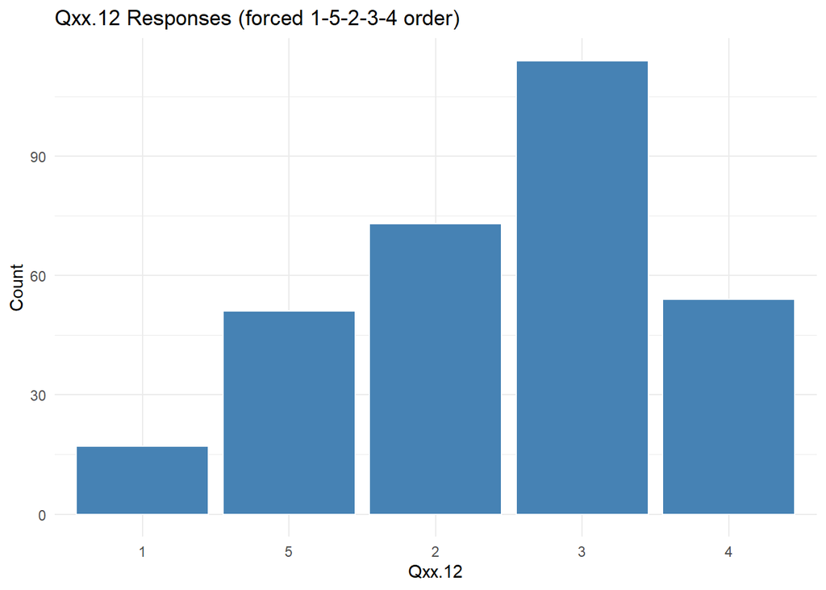

```r
# force order for graph
survey_q12 <- survey_q12 %>%
  mutate(
    q12_value_re = factor(
      q12_value,
      levels = c(1, 5, 2, 3, 4)
    )
  )
# histogram including all participants
ggplot(survey_q12, aes(x = q12_value_re)) +
  geom_bar(fill = "steelblue", color = "white") +
  labs(
    title = "Qxx.12 Responses (forced 1-5-2-3-4 order)",
    x     = "Qxx.12",
    y     = "Count"
  ) +
  theme_minimal()
```

## ! Qxx.14 Probability of higher than 2% target

```r
# combine data from different groups
survey_q14 <- data.frame()
survey_q14_list <- list("Q4.14","Q6.14", "Q8.14", "Q10.14", "Q12.14")
for (i in seq_along(group_list)) {
  df <- group_list[[i]]
  col <- survey_q14_list[[i]]
  temp_table <- df[, c(col, "group")]
  names(temp_table) <- c("q14_value", "group")
  survey_q14 <- rbind(survey_q14, temp_table)
}
survey_q14$q14_value <- as.numeric(survey_q14$q14_value)
```

Test the proportion of correct answer

```r
survey_q14_contingency <- table(survey_q14$q14_value, survey_q14$group)
# print the contingency table
print(survey_q14_contingency)
```

```
##
##     0-controlled 1-errorbar 2-shadedbar 3-fanchartslice 4-bellcurve
##   1           10          1           1               1           4
##   2           21          3           7              14           7
##   3           16         36          29              22          33
##   4            9         10           8              18           2
##   5            3          7          13               8          12
##   6            2          1           3               3           3
##   7            1          1           0               0           0
```

```r
survey_q14_correct <- survey_q14_contingency[3,]
survey_q14_group_total <- colSums(survey_q14_contingency)
prop.test(survey_q14_correct, survey_q14_group_total)
```

```
##
##  5-sample test for equality of proportions without continuity correction
##
## data:  survey_q14_correct out of survey_q14_group_total
## X-squared = 21.144, df = 4, p-value = 0.0002965
## alternative hypothesis: two.sided
## sample estimates:
##    prop 1    prop 2    prop 3    prop 4    prop 5
## 0.2580645 0.6101695 0.4754098 0.3333333 0.5409836
```

Pairwise proportion test

```r
pairwise.prop.test(
  x = survey_q14_contingency[3, ],
  n = colSums(survey_q14_contingency),
  p.adjust.method = "bonferroni" # or "holm", "BH"
)
```

```
##
##  Pairwise comparisons using Pairwise comparison of proportions
##
## data:  survey_q14_contingency[3, ] out of colSums(survey_q14_contingency)
##
##                 0-controlled 1-errorbar 2-shadedbar 3-fanchartslice
## 1-errorbar      0.0019       -          -           -
## 2-shadedbar     0.2062       1.0000     -           -
## 3-fanchartslice 1.0000       0.0352     1.0000      -
## 4-bellcurve     0.0253       1.0000     1.0000      0.2924
##
## P value adjustment method: bonferroni
```

Plot probability of higher than 2% target proportion bar plot across different groups

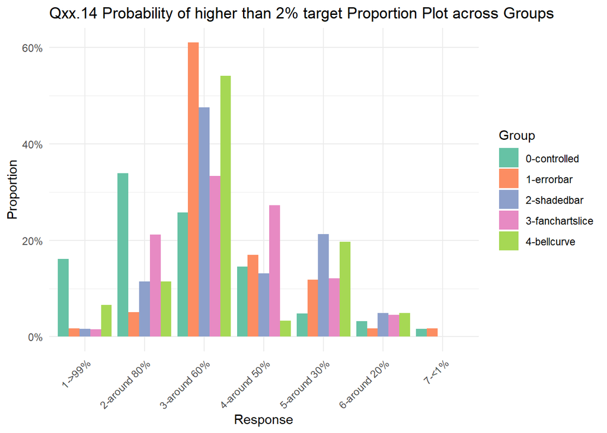

```r
survey_q14_prop  <- as.data.frame(survey_q14_contingency)
# rename columns
names(survey_q14_prop) <- c("Qxx.14", "Group", "Count")
# add a labelled column
survey_q14_prop <- survey_q14_prop %>%
  mutate(Qxx.14_label = case_when(
    Qxx.14 == "1" ~ "1->99%",
    Qxx.14 == "2" ~ "2-around 80%",
    Qxx.14 == "3" ~ "3-around 60%",
    Qxx.14 == "4" ~ "4-around 50%",
    Qxx.14 == "5" ~ "5-around 30%",
    Qxx.14 == "6" ~ "6-around 20%",
    Qxx.14 == "7" ~ "7-<1%"
  ))
# calculate proportions within each group
survey_q14_prop <- survey_q14_prop %>%
  group_by(Group) %>%
  mutate(Proportion = Count / sum(Count))

ggplot(survey_q14_prop, aes(x = as.factor(`Qxx.14_label`), y = Proportion, fill = Group)) + geom_col(position = "dodge") +
  # facet_wrap(~Group)+
  labs(
    title = "Qxx.14 Probability of higher than 2% target Proportion Plot across Groups",
    x = "Response",
    y = "Proportion"
  ) +
   scale_fill_brewer(palette = "Set2")+
  scale_y_continuous(labels = scales::percent_format(accuracy = 1)) +
  theme_minimal()+
  theme(axis.text.x = element_text(angle = 45, hjust = 1))
```

Plot the histogram including all participants

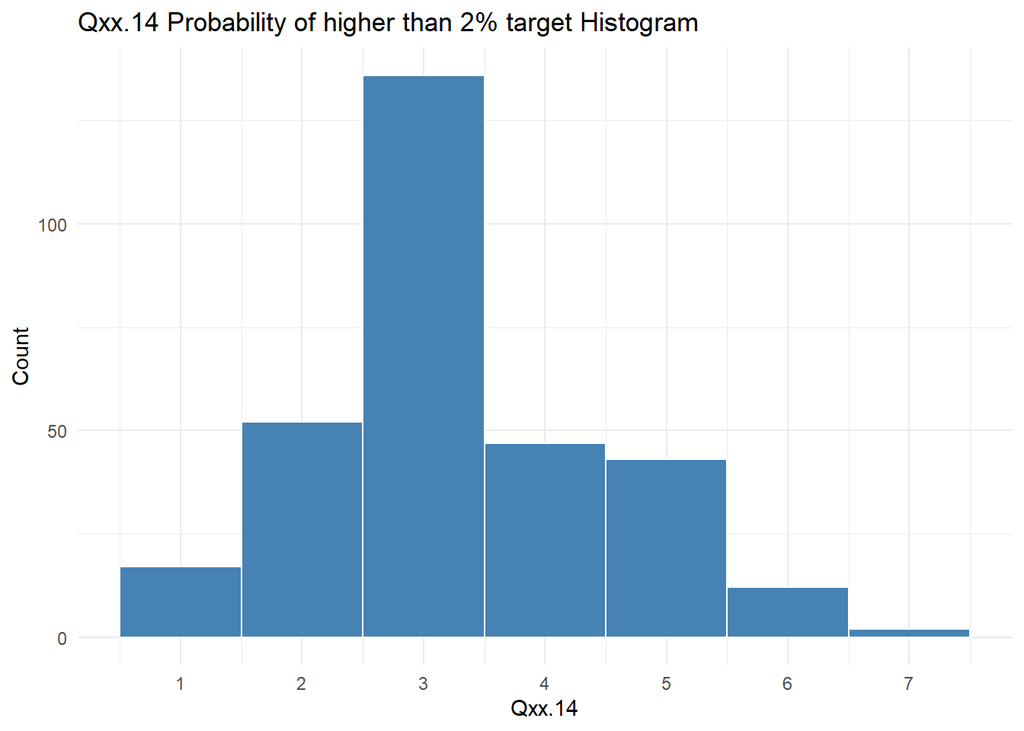

```r
# histogram including all participants
ggplot(survey_q14, aes(x = q14_value)) +
  geom_histogram(binwidth = 1, fill = "steelblue", color = "white") +
  # facet_wrap(~ group) +
  labs(title = "Qxx.14 Probability of higher than 2% target Histogram",
       x = "Qxx.14",
       y = "Count") +
  scale_x_continuous(breaks = seq(0, max(survey_q14$q14_value, na.rm = TRUE), by = 1)) +
  theme_minimal()
```

## Qxx.15 Deviation from central estimate

Based on the inflation forecast provided, do you think there is a higher risk of inflation in 2026Q2 exceeding the central estimate or of being less than this central estimate?  
Definitive Correct Answer - 3  
variable: categorical  
Method: contingency table & proportion test  
**Result: The control group shows significant difference compared to the shaded bar group in terms of the correctly choosing understanding the risk is equal. Among all participants, only around 8% respondents think there is downside risk. The largest proportion (48%) of participants believe there is upside risk.**

```r
# combine data from different groups
survey_q15 <- data.frame()
survey_q15_list <- list("Q4.15","Q6.15", "Q8.15", "Q10.15", "Q12.15")
for (i in seq_along(group_list)) {
  df <- group_list[[i]]
  col <- survey_q15_list[[i]]
  temp_table <- df[, c(col, "group")]
  names(temp_table) <- c("q15_value", "group")
  survey_q15 <- rbind(survey_q15, temp_table)
}
survey_q15$q15_value <- as.numeric(survey_q15$q15_value)
```

Contingency table

```r
survey_q15_contingency <- table(survey_q15$q15_value, survey_q15$group)
# print the contingency table
print(survey_q15_contingency)
```

```
##
##     0-controlled 1-errorbar 2-shadedbar 3-fanchartslice 4-bellcurve
##   1           43         25          19              29          31
##   2            2          7           6               4           7
##   3           17         27          36              33          23
```

```r
# chi-squared test
chisq_result <- chisq.test(survey_q15_contingency)
std_resid <- chisq_result$stdres
print(std_resid)
```

```
##
##     0-controlled 1-errorbar 2-shadedbar 3-fanchartslice 4-bellcurve
##   1    3.8412018 -0.8891507  -2.8673008      -0.6665092   0.5667920
##   2   -1.6460439  1.0613387   0.4465225      -0.7767218   0.9613564
##   3   -2.9439670  0.3010103   2.6349682       1.1049110  -1.1078420
```

```r
# correct answer
survey_q15_correct <- survey_q15_contingency[3,]
survey_q15_group_total <- colSums(survey_q15_contingency)
prop.test(survey_q15_correct, survey_q15_group_total)
```

```
##
##  5-sample test for equality of proportions without continuity correction
##
## data:  survey_q15_correct out of survey_q15_group_total
## X-squared = 14.519, df = 4, p-value = 0.005811
## alternative hypothesis: two.sided
## sample estimates:
##    prop 1    prop 2    prop 3    prop 4    prop 5
## 0.2741935 0.4576271 0.5901639 0.5000000 0.3770492
```

Pairwise proportion test

```r
pairwise.prop.test(
  x = survey_q15_contingency[3, ],
  n = colSums(survey_q15_contingency),
  p.adjust.method = "bonferroni" # or "holm", "BH"
)
```

```
##
##  Pairwise comparisons using Pairwise comparison of proportions
##
## data:  survey_q15_contingency[3, ] out of colSums(survey_q15_contingency)
##
##                 0-controlled 1-errorbar 2-shadedbar 3-fanchartslice
## 1-errorbar      0.5644       -          -           -
## 2-shadedbar     0.0079       1.0000     -           -
## 3-fanchartslice 0.1487       1.0000     1.0000      -
## 4-bellcurve     1.0000       1.0000     0.2970      1.0000
##
## P value adjustment method: bonferroni
```

Plot proportion bar plot across different groups

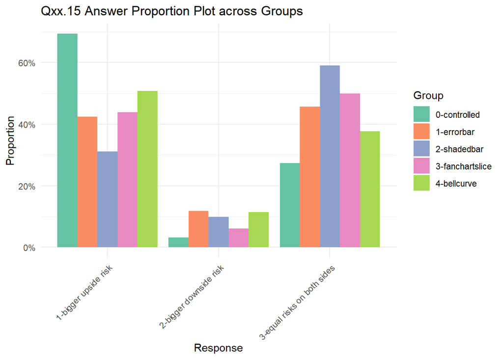

```r
survey_q15_prop  <- as.data.frame(survey_q15_contingency)
# rename columns
names(survey_q15_prop) <- c("Qxx.15", "Group", "Count")
# add a labelled column
survey_q15_prop <- survey_q15_prop %>%
  mutate(Qxx.15_label = case_when(
    Qxx.15 == "1" ~ "1-bigger upside risk",
    Qxx.15 == "2" ~ "2-bigger downside risk",
    Qxx.15 == "3" ~ "3-equal risks on both sides"
  ))
# calculate proportions within each group
survey_q15_prop <- survey_q15_prop %>%
  group_by(Group) %>%
  mutate(Proportion = Count / sum(Count))
ggplot(survey_q15_prop, aes(x = as.factor(`Qxx.15_label`), y = Proportion, fill = Group)) + geom_col(position = "dodge") +
  # facet_wrap(~Group)+
  labs(
    title = "Qxx.15 Answer Proportion Plot across Groups",
    x = "Response",
    y = "Proportion"
  ) +
   scale_fill_brewer(palette = "Set2")+
  scale_y_continuous(labels = scales::percent_format(accuracy = 1)) +
  theme_minimal()+
  theme(axis.text.x = element_text(angle = 45, hjust = 1))
```

Plot the histogram including all participants

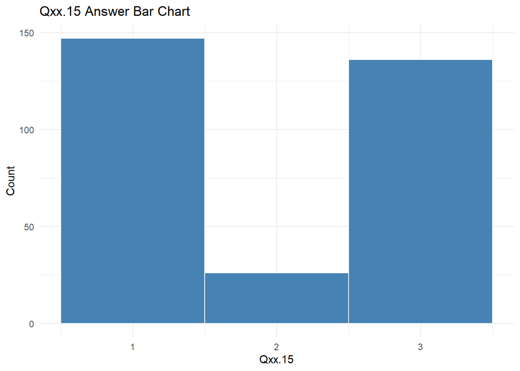

```r
# histogram including all participants
ggplot(survey_q15, aes(x = q15_value)) +
  geom_histogram(binwidth = 1, fill = "steelblue", color = "white") +
  # facet_wrap(~ group) +
  labs(title = "Qxx.15 Answer Bar Chart",
       x = "Qxx.15",
       y = "Count") +
  scale_x_continuous(breaks = seq(0, max(survey_q15$q15_value, na.rm = TRUE), by = 1)) +
  theme_minimal()
```

```r
# combine data from different groups
survey_q17 <- data.frame()
survey_q17_list <- list("Q4.17_1","Q6.17_1", "Q8.17_1", "Q10.17_1", "Q12.17_1")
for (i in seq_along(group_list)) {
  df <- group_list[[i]]
  col <- survey_q17_list[[i]]
  temp_table <- df[, c(col, "group")]
  names(temp_table) <- c("q17_value", "group")
  survey_q17 <- rbind(survey_q17, temp_table)
}
survey_q17$q17_value <- as.numeric(survey_q17$q17_value)

#initial check
summary(survey_q17$q17_value)
```

```
##    Min. 1st Qu.  Median    Mean 3rd Qu.    Max.
##       9      10      11      11      12      15
```

Summary Table

```r
survey_q17_summary <- survey_q17 %>%
  group_by(group) %>%
  summarise(
    median = median(q17_value, na.rm = TRUE),
    IQR    = IQR(q17_value,   na.rm = TRUE),  # same as Q3 − Q1
    Q1     = quantile(q17_value, 0.25, na.rm = TRUE),
    Q3     = quantile(q17_value, 0.75, na.rm = TRUE)
  )
print(survey_q17_summary)
```

```
## # A tibble: 5 × 5
##   group           median   IQR    Q1    Q3
##   <chr>            <dbl> <dbl> <dbl> <dbl>
## 1 0-controlled        11     2    10    12
## 2 1-errorbar          11     2    10    12
## 3 2-shadedbar         11     2    10    12
## 4 3-fanchartslice     11     2    10    12
## 5 4-bellcurve         11     2    10    12
```

KW test

```r
# check normality --> the data is not normally distributed
# shapiro.test(survey_q17$q17_value)

# run Kruskal-Wallis test
kruskal_test <- kruskal.test(q17_value ~ group, data = survey_q17)
print(kruskal_test)
```

```
##
##  Kruskal-Wallis rank sum test
##
## data:  q17_value by group
## Kruskal-Wallis chi-squared = 1.4881, df = 4, p-value = 0.8287
```

```r
# Effect size
kw_es  <- kruskal_effsize(q17_value ~ group, data = survey_q17, ci = TRUE)
print(kw_es)
```

```
## # A tibble: 1 × 7
##   .y.           n  effsize conf.low conf.high method  magnitude
## * <chr>     <int>    <dbl>    <dbl>     <dbl> <chr>   <ord>
## 1 q17_value   309 -0.00826    -0.01      0.04 eta2[H] small
```

Plot the distribution of different groups

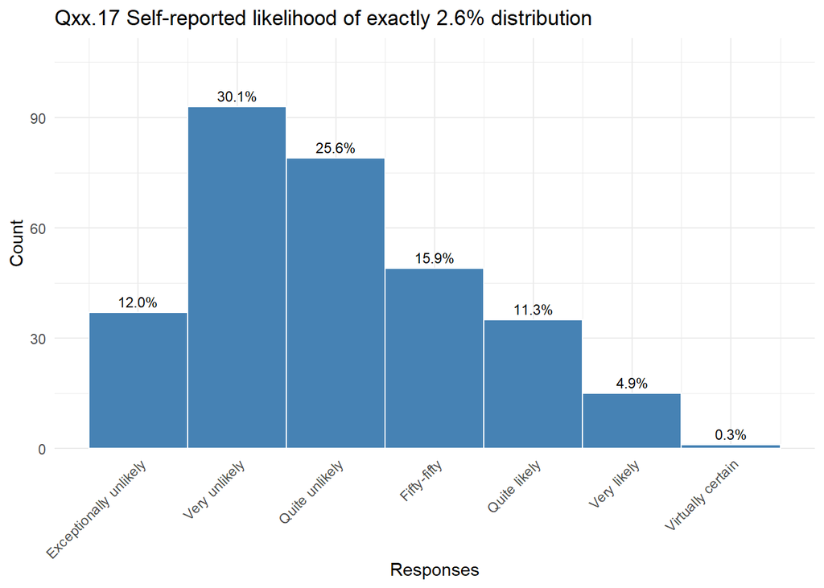

```r
# histogram including all participants
ggplot(survey_q17, aes(x = q17_value)) +
  geom_histogram(binwidth = 1, fill = "steelblue", color = "white") +
    geom_text(
    stat      = "count",
    aes(label = scales::percent(after_stat(count / total_respondents), accuracy = 0.1)),
    position  = position_dodge(width = 0.9),
    vjust     = -0.5,
    size      = 3
  ) +
  # facet_wrap(~ group) +
  scale_y_continuous(
    expand = expansion(mult = c(0, 0.2)))+
  labs(title = "Qxx.17 Self-reported likelihood of exactly 2.6% distribution",
       x = "Responses",
       y = "Count") +
  scale_x_continuous(breaks = as.numeric(names(likelihood_labels)),
                     labels = likelihood_labels) +
  theme_minimal() +
  theme(axis.text.x = element_text(angle = 45, hjust = 1))
```

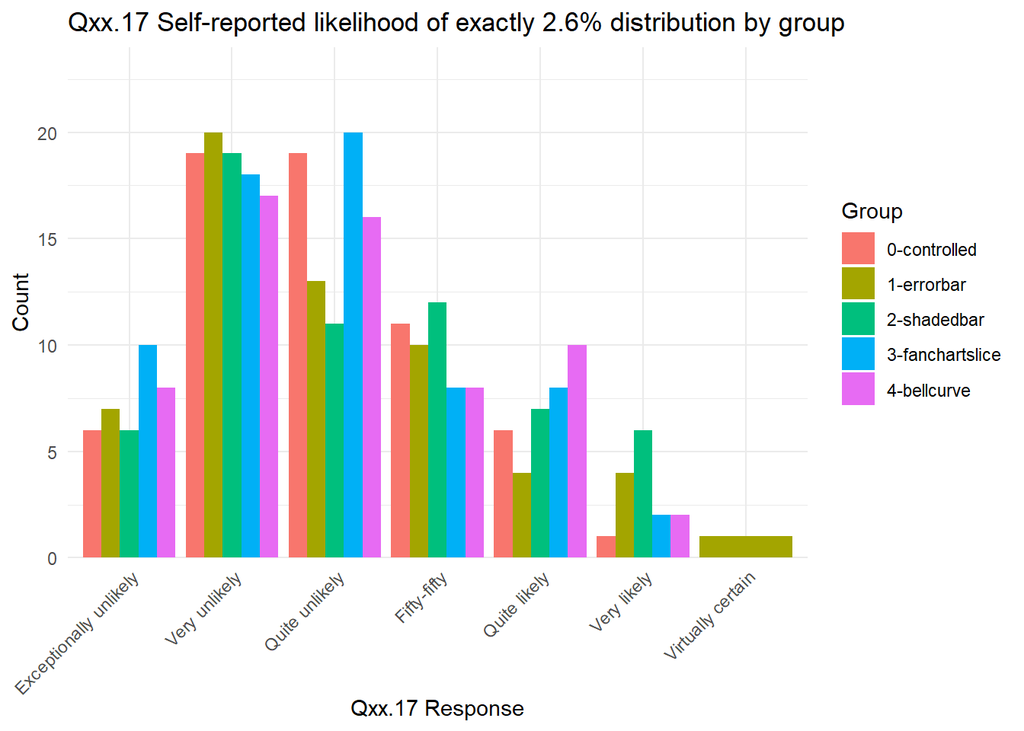

```r
# Grouped bar-style histogram
ggplot(survey_q17, aes(x = factor(q17_value), fill = factor(group))) +
  geom_bar(position = "dodge") +
  # facet_wrap(~ group) +
    scale_y_continuous(
    expand = expansion(mult = c(0, 0.2)))+
  # add labels
  scale_x_discrete(labels=likelihood_labels) +
  labs(
    title = "Qxx.17 Self-reported likelihood of exactly 2.6% distribution by group",
    x = "Qxx.17 Response",
    y = "Count",
    fill = "Group"
  ) +
  theme_minimal() +
  theme(axis.text.x = element_text(angle = 45, hjust = 1))
```

## Qxx.19 Rationale for the likelihood of inflation being exactly 2.6% What tells you that the inflation in 2026Q2 is likely or unlikely to be exactly 2.6%? (Please select the option that best reflects your belief, even if other answers may also seem reasonable.) - Selected Choice  
Variable: categorical  
Method: contingency table + Not comparable across group  
Function:

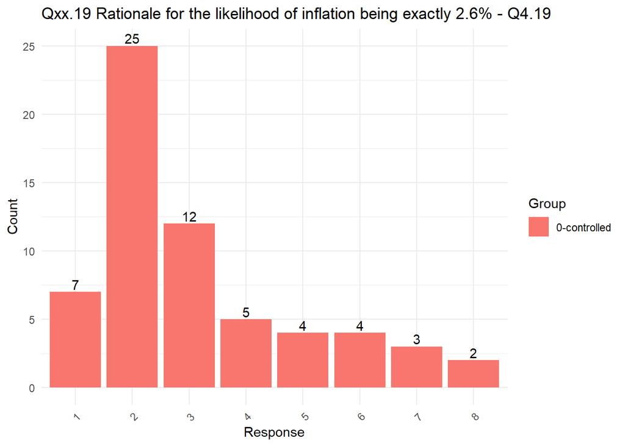

```r
plot_survey_q19 <- function(survey_data, question_header){
  survey_q19 <- survey_data[, c(question_header, "group")]
  survey_q19_contingency <- table(survey_q19[[question_header]], survey_q19$group)

  # visualise the contingency table as a bar plot
  ggplot(as.data.frame(survey_q19_contingency), aes(x = Var1, y = Freq, fill = Var2)) +  geom_text(aes(label = Freq),
                 vjust = -0.25                                                                                  )+
    geom_bar(stat = "identity", position = "dodge") +
    labs(title = paste("Qxx.19 Rationale for the likelihood of inflation being exactly 2.6% -", question_header),
         x = "Response",
         y = "Count",
         fill = "Group") +
    theme_minimal() +
    theme(axis.text.x = element_text(angle = 45, hjust = 1))
}
plot_survey_q19(controlled_group, "Q4.19")
```

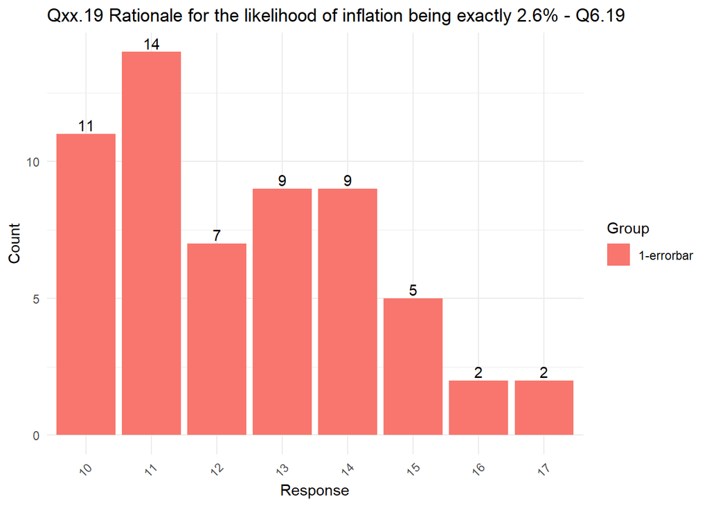

```r
plot_survey_q19(error_bar, "Q6.19")
```

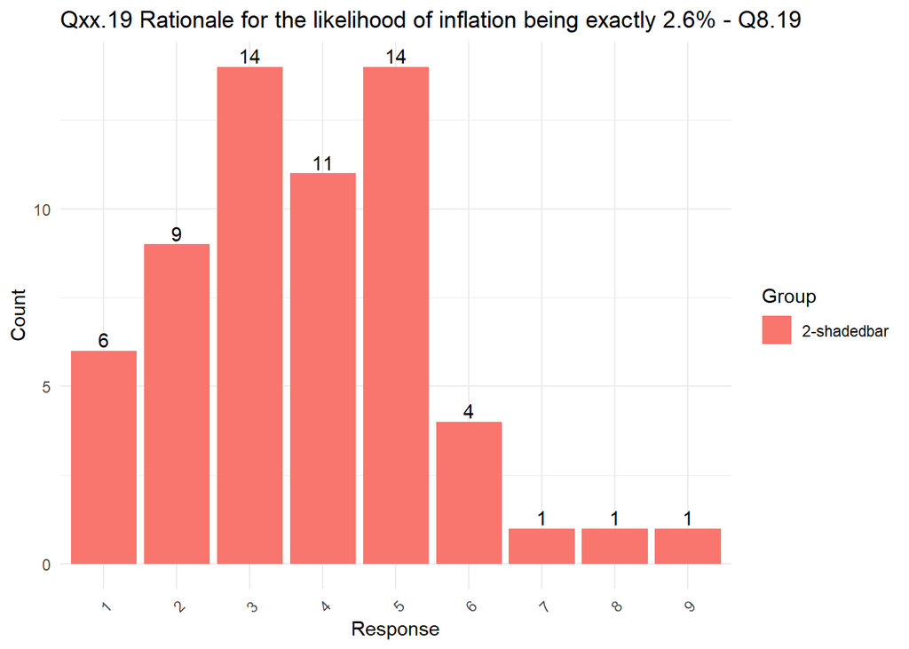

```r
plot_survey_q19(shaded_bar, "Q8.19")
```

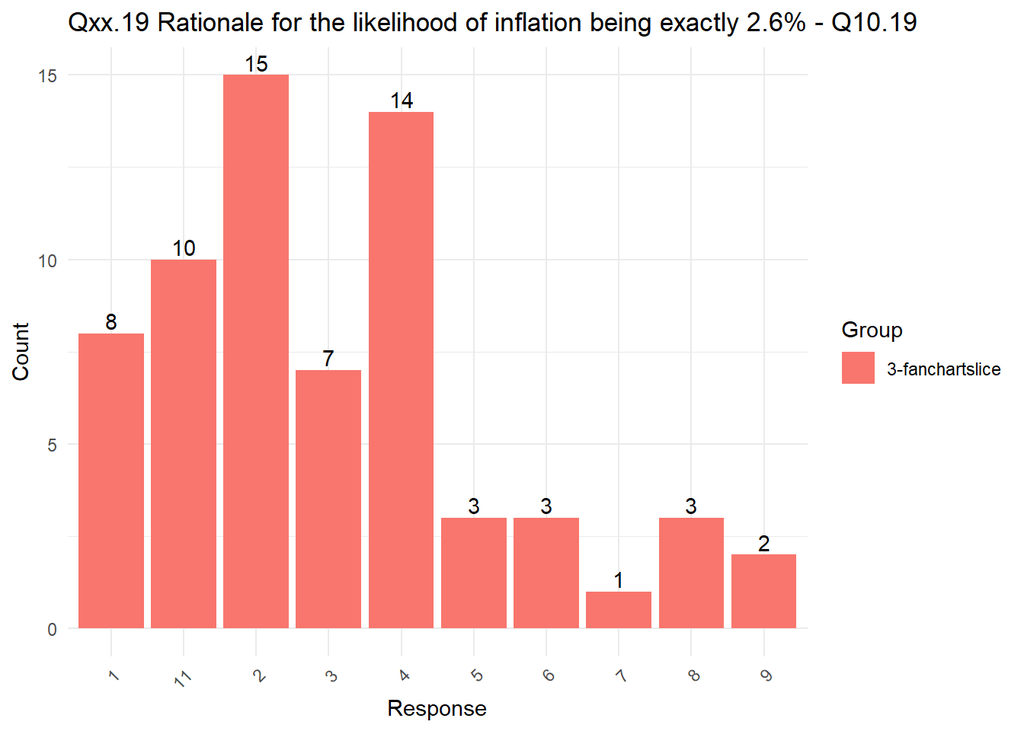

```r
plot_survey_q19(fanchart_slice, "Q10.19")
```

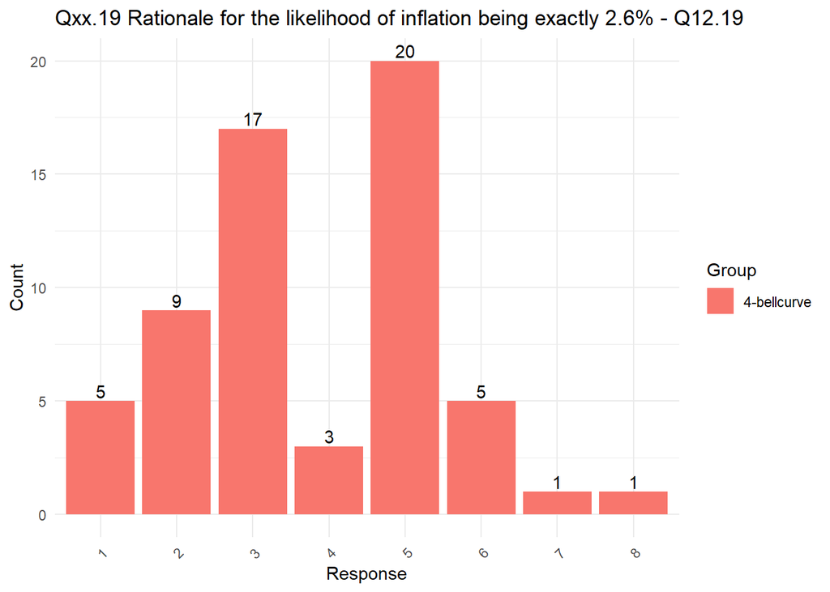

```r
plot_survey_q19(bell_curve, "Q12.19")
```

## Qxx.21 Self-reported likelihood of inflation being between 1.9% and 3.3%

```r
# combine data from different groups
survey_q21 <- data.frame()
survey_q21_list <- list("Q4.21_1","Q6.21_1", "Q8.21_1", "Q10.21_1", "Q12.21_1")
for (i in seq_along(group_list)) {
  df <- group_list[[i]]
  col <- survey_q21_list[[i]]
  temp_table <- df[, c(col, "group")]
  names(temp_table) <- c("q21_value", "group")
  survey_q21 <- rbind(survey_q21, temp_table)
}
survey_q21$q21_value <- as.numeric(survey_q21$q21_value)
```

Summary Table

```r
survey_q21_summary <- survey_q21 %>%
  group_by(group) %>%
  summarise(
    median = median(q21_value, na.rm = TRUE),
    IQR    = IQR(q21_value,   na.rm = TRUE),  # same as Q3 − Q1
    Q1     = quantile(q21_value, 0.25, na.rm = TRUE),
    Q3     = quantile(q21_value, 0.75, na.rm = TRUE)
  )
print(survey_q21_summary)
```

```
## # A tibble: 5 × 5
##   group           median   IQR    Q1    Q3
##   <chr>            <dbl> <dbl> <dbl> <dbl>
## 1 0-controlled        13     1    13    14
## 2 1-errorbar          13     1    12    13
## 3 2-shadedbar         13     2    12    14
## 4 3-fanchartslice     13     2    12    14
## 5 4-bellcurve         13     1    12    13
```

KW test

```r
# summary(survey_q21)
# check normality --> the data is not normally distributed
# shapiro.test(survey_q21$q21_value)

# run Kruskal-Wallis test
kruskal_test <- kruskal.test(q21_value ~ group, data = survey_q21)
print(kruskal_test)
```

```
##
##  Kruskal-Wallis rank sum test
##
## data:  q21_value by group
## Kruskal-Wallis chi-squared = 8.6617, df = 4, p-value = 0.07013
```

```r
# Effect size
kw_es  <- kruskal_effsize(q21_value ~ group, data = survey_q21, ci = TRUE)
print(kw_es)
```

```
## # A tibble: 1 × 7
##   .y.           n effsize conf.low conf.high method  magnitude
## * <chr>     <int>   <dbl>    <dbl>     <dbl> <chr>   <ord>
## 1 q21_value   309  0.0153   -0.004      0.07 eta2[H] small
```

Plot the distribution of different groups

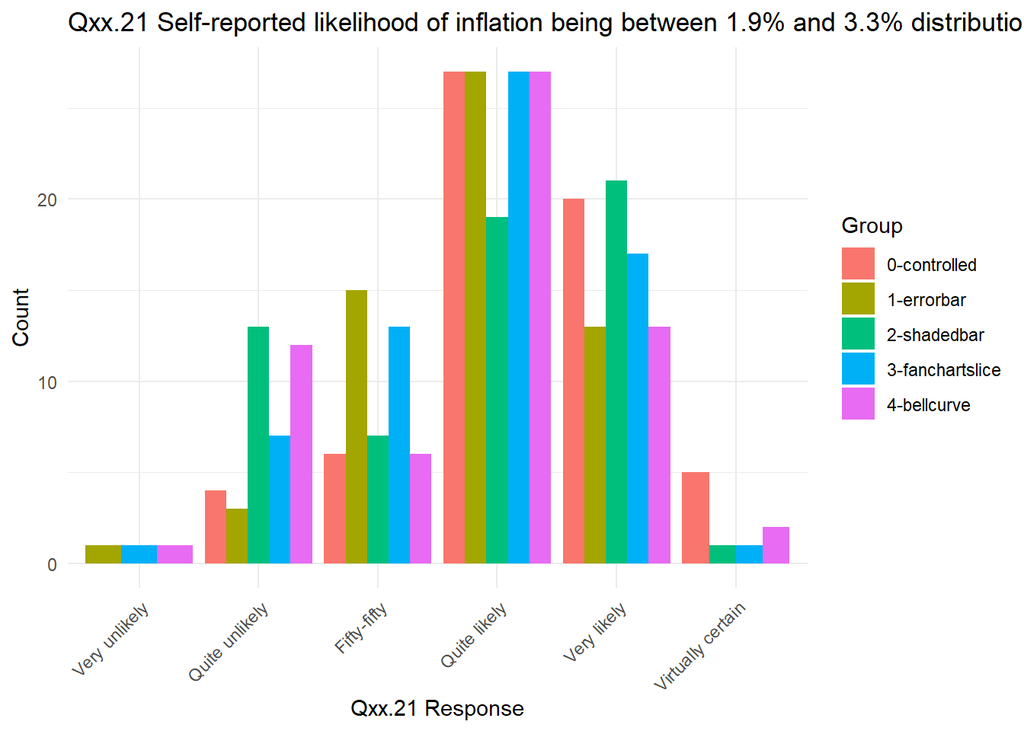

```r
# Grouped bar-style histogram
ggplot(survey_q21, aes(x = factor(q21_value), fill = factor(group))) +
  geom_bar(position = "dodge") +
  # facet_wrap(~ group) +
  # add labels
  scale_x_discrete(labels=likelihood_labels) +
  labs(
    title = "Qxx.21 Self-reported likelihood of inflation being between 1.9% and 3.3% distribution by group",
    x = "Qxx.21 Response",
    y = "Count",
    fill = "Group"
  ) +
  theme_minimal() +
  theme(axis.text.x = element_text(angle = 45, hjust = 1))
```

Plot bar chart including all participants

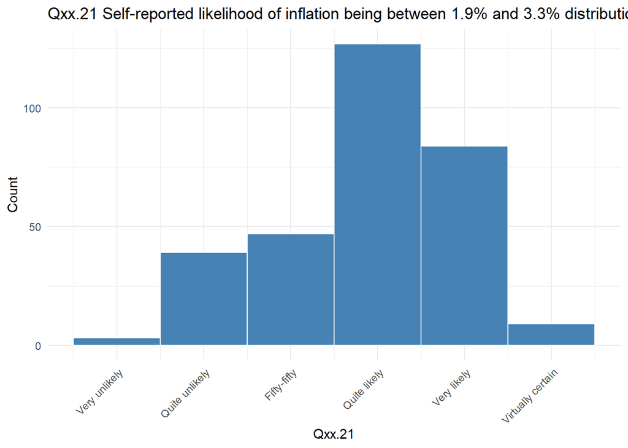

```r
# histogram including all participants
ggplot(survey_q21, aes(x = q21_value)) +
  geom_histogram(binwidth = 1, fill = "steelblue", color = "white") +
  # facet_wrap(~ group) +
  labs(title = "Qxx.21 Self-reported likelihood of inflation being between 1.9% and 3.3% distribution",
       x = "Qxx.21",
       y = "Count") +
  scale_x_continuous(breaks = as.numeric(names(likelihood_labels)),
                     labels = likelihood_labels) +
  theme_minimal() +
  theme(axis.text.x = element_text(angle = 45, hjust = 1))
```

## ! Qxx.22 Self-reported likelihood of inflation being between 3.3% and 5.6% How likely do you think it is that the inflation will be between 3.3% and 5.6%?  
*ascending value-increasing likelihood*  
Variable: treat as continuous  
Method: Kruskal-Wallis test  
**Result: The distribution of shaded bar group and bell curve show statistical difference. Near half of the respondents think it’s quite unlikely.**

```r
# combine data from different groups
survey_q22 <- data.frame()
survey_q22_list <- list("Q4.22_1","Q6.22_1", "Q8.22_1", "Q10.22_1", "Q12.22_1")
for (i in seq_along(group_list)) {
  df <- group_list[[i]]
  col <- survey_q22_list[[i]]
  temp_table <- df[, c(col, "group")]
  names(temp_table) <- c("q22_value", "group")
  survey_q22 <- rbind(survey_q22, temp_table)
}
survey_q22$q22_value <- as.numeric(survey_q22$q22_value)
summary(survey_q22$q22_value)
```

```
##    Min. 1st Qu.  Median    Mean 3rd Qu.    Max.
##    9.00   11.00   11.00   11.36   12.00   15.00
```

Summary Table

```r
survey_q22_summary <- survey_q22 %>%
  group_by(group) %>%
  summarise(
    median = median(q22_value, na.rm = TRUE),
    IQR    = IQR(q22_value,   na.rm = TRUE),  # same as Q3 − Q1
    Q1     = quantile(q22_value, 0.25, na.rm = TRUE),
    Q3     = quantile(q22_value, 0.75, na.rm = TRUE),
    mean   = mean(q22_value, na.rm = TRUE),
  )
print(survey_q22_summary)
```

```
## # A tibble: 5 × 6
##   group           median   IQR    Q1    Q3  mean
##   <chr>            <dbl> <dbl> <dbl> <dbl> <dbl>
## 1 0-controlled        11     1    11    12  11.3
## 2 1-errorbar          11     1    11    12  11.3
## 3 2-shadedbar         11     0    11    11  11.1
## 4 3-fanchartslice     11     1    11    12  11.4
## 5 4-bellcurve         11     2    11    13  11.7
```

KW test

```r
# check normality --> the data is not normally distributed
# shapiro.test(survey_q22$q22_value)

# run Kruskal-Wallis test
kruskal_test <- kruskal.test(q22_value ~ group, data = survey_q22)
print(kruskal_test)
```

```
##
##  Kruskal-Wallis rank sum test
##
## data:  q22_value by group
## Kruskal-Wallis chi-squared = 9.8534, df = 4, p-value = 0.04297
```

```r
# Effect size
kw_es  <- kruskal_effsize(q22_value ~ group, data = survey_q22, ci = TRUE)
print(kw_es)
```

```
## # A tibble: 1 × 7
##   .y.           n effsize conf.low conf.high method  magnitude
## * <chr>     <int>   <dbl>    <dbl>     <dbl> <chr>   <ord>
## 1 q22_value   309  0.0193  -0.0038      0.08 eta2[H] small
```

```r
# Post-hoc test
dunnTest(q22_value ~ group, data = survey_q22, method = "bonferroni")
```

```
## Dunn (1964) Kruskal-Wallis multiple comparison
```

```
##   p-values adjusted with the Bonferroni method.
```

```
##                        Comparison          Z     P.unadj      P.adj
## 1       0-controlled - 1-errorbar  0.3519613 0.724867319 1.00000000
## 2      0-controlled - 2-shadedbar  1.0909284 0.275304410 1.00000000
## 3        1-errorbar - 2-shadedbar  0.7268652 0.467308520 1.00000000
## 4  0-controlled - 3-fanchartslice -0.5808237 0.561359281 1.00000000
## 5    1-errorbar - 3-fanchartslice -0.9306361 0.352041833 1.00000000
## 6   2-shadedbar - 3-fanchartslice -1.6860866 0.091779118 0.91779118
## 7      0-controlled - 4-bellcurve -1.8775914 0.060437079 0.60437079
## 8        1-errorbar - 4-bellcurve -2.2049193 0.027459761 0.27459761
## 9       2-shadedbar - 4-bellcurve -2.9565257 0.003111263 0.03111263
## 10  3-fanchartslice - 4-bellcurve -1.3280766 0.184152801 1.00000000
```

Plot the distribution of different groups

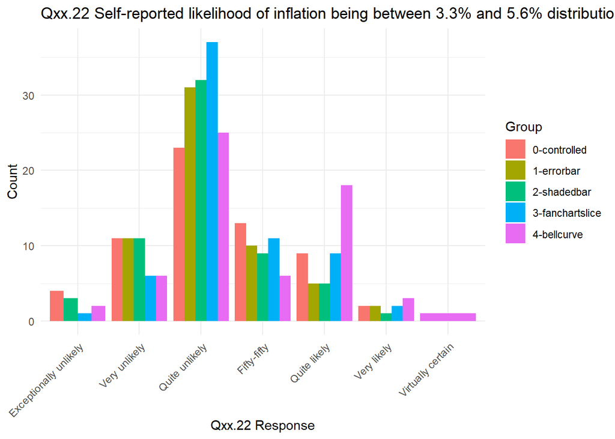

```r
# Grouped bar-style histogram
ggplot(survey_q22, aes(x = factor(q22_value), fill = factor(group))) +
  geom_bar(position = "dodge") +
  # facet_wrap(~ group) +
  # add labels
  scale_x_discrete(labels=likelihood_labels) +
  labs(
    title = "Qxx.22 Self-reported likelihood of inflation being between 3.3% and 5.6% distribution by group",
    x = "Qxx.22 Response",
    y = "Count",
    fill = "Group"
  ) +
  theme_minimal() +
  theme(axis.text.x = element_text(angle = 45, hjust = 1))
```

Plot bar chart including all participants

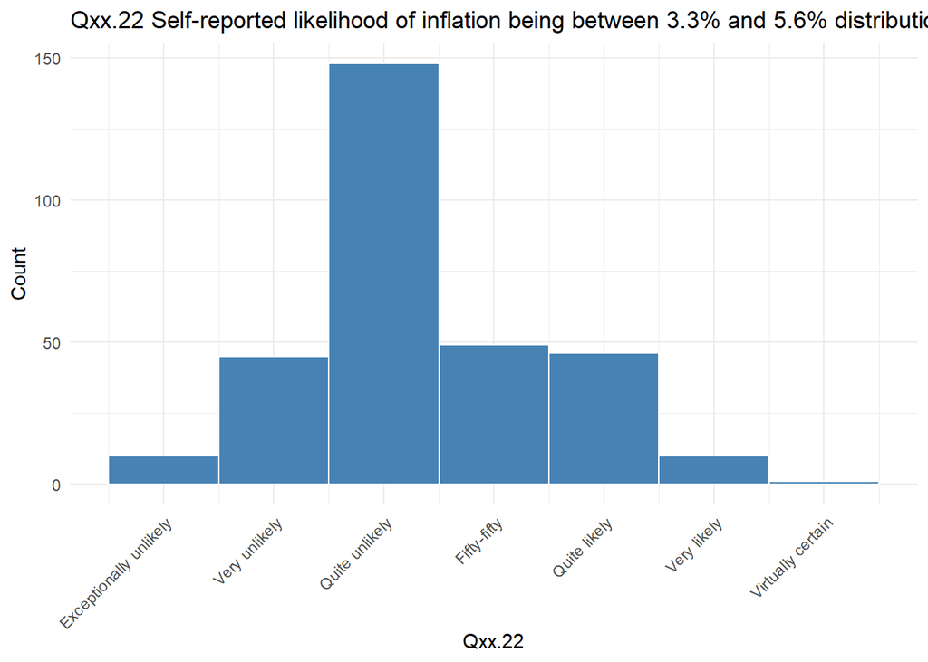

```r
# histogram including all participants
ggplot(survey_q22, aes(x = q22_value)) +
  geom_histogram(binwidth = 1, fill = "steelblue", color = "white") +
  # facet_wrap(~ group) +
  labs(title = "Qxx.22 Self-reported likelihood of inflation being between 3.3% and 5.6% distribution",
       x = "Qxx.22",
       y = "Count") +
  scale_x_continuous(breaks = as.numeric(names(likelihood_labels)),
                     labels = likelihood_labels) +
  theme_minimal() +
  theme(axis.text.x = element_text(angle = 45, hjust = 1))
```

```r
# combine data from different groups
survey_q23 <- data.frame()
survey_q23_list <- list("Q4.23_1","Q6.23_1", "Q8.23_1", "Q10.23_1", "Q12.23_1")
for (i in seq_along(group_list)) {
  df <- group_list[[i]]
  col <- survey_q23_list[[i]]
  temp_table <- df[, c(col, "group")]
  names(temp_table) <- c("q23_value", "group")
  survey_q23 <- rbind(survey_q23, temp_table)
}
survey_q23$q23_value <- as.numeric(survey_q23$q23_value)
summary(survey_q23$q23_value)
```

```
##    Min. 1st Qu.  Median    Mean 3rd Qu.    Max.
##     9.0    11.0    12.0    11.9    13.0    15.0
```

Summary Table

```r
survey_q23_summary <- survey_q23 %>%
  group_by(group) %>%
  summarise(
    median = median(q23_value, na.rm = TRUE),
    IQR    = IQR(q23_value,   na.rm = TRUE),  # same as Q3 − Q1
    Q1     = quantile(q23_value, 0.25, na.rm = TRUE),
    Q3     = quantile(q23_value, 0.75, na.rm = TRUE)
  )
print(survey_q23_summary)
```

```
## # A tibble: 5 × 5
##   group           median   IQR    Q1    Q3
##   <chr>            <dbl> <dbl> <dbl> <dbl>
## 1 0-controlled        12     2    11    13
## 2 1-errorbar          12     2    11    13
## 3 2-shadedbar         12     1    11    12
## 4 3-fanchartslice     12     2    11    13
## 5 4-bellcurve         12     2    11    13
```

KW test

```r
# check normality --> the data is not normally distributed
# shapiro.test(survey_q23$q23_value)

# initial check
summary(survey_q23)
```

```
##    q23_value       group
##  Min.   : 9.0   Length:309
##  1st Qu.:11.0   Class :character
##  Median :12.0   Mode  :character
##  Mean   :11.9
##  3rd Qu.:13.0
##  Max.   :15.0
```

```r
# run Kruskal-Wallis test
kruskal_test <- kruskal.test(q23_value ~ group, data = survey_q23)
print(kruskal_test)
```

```
##
##  Kruskal-Wallis rank sum test
##
## data:  q23_value by group
## Kruskal-Wallis chi-squared = 3.1999, df = 4, p-value = 0.525
```

```r
# Effect size
kw_es  <- kruskal_effsize(q23_value ~ group, data = survey_q23, ci = TRUE)
print(kw_es)
```

```
## # A tibble: 1 × 7
##   .y.           n  effsize conf.low conf.high method  magnitude
## * <chr>     <int>    <dbl>    <dbl>     <dbl> <chr>   <ord>
## 1 q23_value   309 -0.00263  -0.0098      0.05 eta2[H] small
```

Plot the distribution of different groups

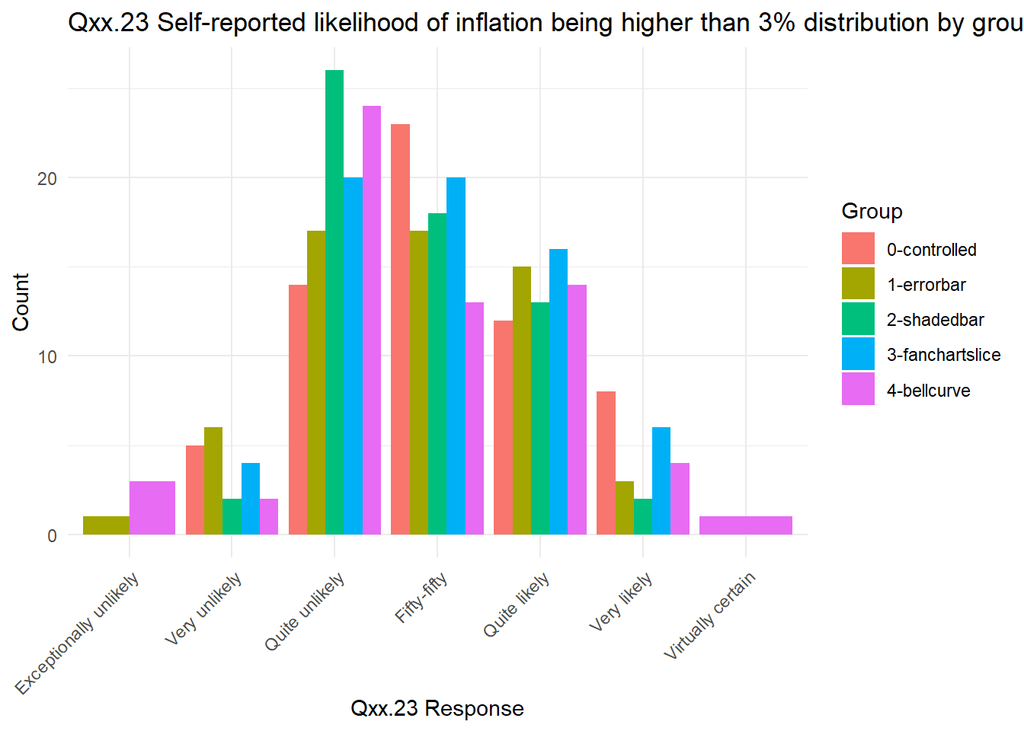

```r
# Grouped bar-style histogram
ggplot(survey_q23, aes(x = factor(q23_value), fill = factor(group))) +
  geom_bar(position = "dodge") +
  # facet_wrap(~ group) +
  # add labels
  scale_x_discrete(labels=likelihood_labels) +
  labs(
    title = "Qxx.23 Self-reported likelihood of inflation being higher than 3% distribution by group",
    x = "Qxx.23 Response",
    y = "Count",
    fill = "Group"
  ) +
  theme_minimal() +
  theme(axis.text.x = element_text(angle = 45, hjust = 1))
```

Plot bar chart including all participants

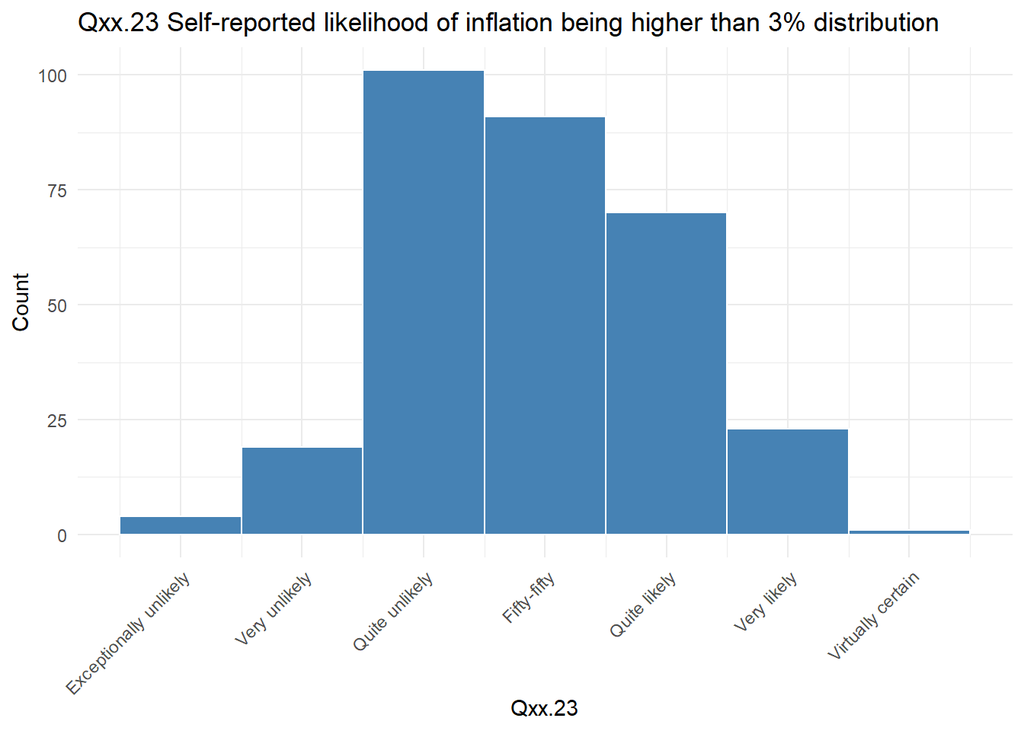

```r
# histogram including all participants
ggplot(survey_q23, aes(x = q23_value)) +
  geom_histogram(binwidth = 1, fill = "steelblue", color = "white") +
  # facet_wrap(~ group) +
  labs(title = "Qxx.23 Self-reported likelihood of inflation being higher than 3% distribution",
       x = "Qxx.23",
       y = "Count") +
  scale_x_continuous(breaks = as.numeric(names(likelihood_labels)),
                     labels = likelihood_labels) +
  theme_minimal() +
  theme(axis.text.x = element_text(angle = 45, hjust = 1))
```

## ! Qxx.24 Ranking

Based on the inflation forecast provided, please rank the following inflation rates from most likely to least likely to occur: 0.8%, 2.5%, 3.9% and 6.5%. - 0.8%  
*Lower mean rank = more preferred*  
Method: Mean Rank

```r
# combine data from different groups
survey_q24 <- controlled_group[, c("Q4.24_1", "Q4.24_2", "Q4.24_3", "Q4.24_4")]
survey_q24 <- as.data.frame(lapply(survey_q24, as.numeric))
mean_rank <- colMeans(survey_q24, na.rm = TRUE)

rank_summary_controlled <- data.frame(
  Item = c("0.8%", "2.5%", "3.9%", "6.5%"),
  MeanRank = mean_rank
)
```

combine into one table

```r
# main code
q24_prefixes <- list("Q4.24", "Q6.24", "Q8.24", "Q10.24", "Q12.24")
rank_summary <- data.frame(
  Item = c("0.8%", "2.5%", "3.9%", "6.5%")
)
survey_q24 <- data.frame()

for (i in seq_along(group_list)) {
  group_name <- names(group_list)[i]
  df <- group_list[[i]]
  q_cols <- paste0(q24_prefixes[[i]], "_", 1:4)
  temp_table <- df[, c(q_cols, "group", "treatment")]
  # combine the data
  names(temp_table) <- c("Qxx.24_1", "Qxx.24_2", "Qxx.24_3", "Qxx.24_4", "group", "treatment")
  temp_table[, c("Qxx.24_1", "Qxx.24_2", "Qxx.24_3", "Qxx.24_4")] <-
  lapply(temp_table[, c("Qxx.24_1", "Qxx.24_2", "Qxx.24_3", "Qxx.24_4")], as.numeric)
  survey_q24 <- rbind(survey_q24, temp_table)

  # mean rank
  df <- as.data.frame(lapply(df[,q_cols], as.numeric))
  mean_rank <- colMeans(df, na.rm = TRUE)
  rank_summary[[group_name]] <- mean_rank
}

# overall means
overall_means <- rowMeans(rank_summary[, -1], na.rm = TRUE)
rank_summary <- cbind(rank_summary, overall = overall_means)

  # correct answer
survey_q24_correct_prop <- survey_q24 %>%
  group_by(group) %>%
  summarise(
    total = n(),
    correct = sum(
      Qxx.24_1 == 3 & Qxx.24_2 == 1 & Qxx.24_3 == 2 & Qxx.24_4 == 4,
      na.rm = TRUE
    ),
    proportion_correct = correct / total,
    .groups = "drop"
  )
```

proportion test

```r
prop.test(
  x = survey_q24_correct_prop$correct,
  n = survey_q24_correct_prop$total
)
```

```
##
##  5-sample test for equality of proportions without continuity correction
##
## data:  survey_q24_correct_prop$correct out of survey_q24_correct_prop$total
## X-squared = 11.062, df = 4, p-value = 0.02588
## alternative hypothesis: two.sided
## sample estimates:
##    prop 1    prop 2    prop 3    prop 4    prop 5
## 0.4032258 0.5084746 0.6557377 0.4696970 0.6229508
```

```r
# pairwise proportion test
pairwise.prop.test(
  x = survey_q24_correct_prop$correct,
  n = survey_q24_correct_prop$total,
  p.adjust.method = "bonferroni" # or "holm", "BH"
)
```

```
##
##  Pairwise comparisons using Pairwise comparison of proportions
##
## data:  survey_q24_correct_prop$correct out of survey_q24_correct_prop$total
##
##   1     2     3     4
## 2 1.000 -     -     -
## 3 0.087 1.000 -     -
## 4 1.000 1.000 0.535 -
## 5 0.240 1.000 1.000 1.000
##
## P value adjustment method: bonferroni
```

Proportion of correct answer

```r
survey_q24 <- controlled_group[, c("Q4.24_1", "Q4.24_2", "Q4.24_3", "Q4.24_4")]
survey_q24 <- as.data.frame(lapply(survey_q24, as.numeric))
survey_q24_correct <- survey_q24[survey_q24$Q4.24_1 == 3 & survey_q24$Q4.24_2 == 1 & survey_q24$Q4.24_3 == 2 & survey_q24$Q4.24_4 == 4, ]
proportion_correct <- nrow(survey_q24_correct) / nrow(survey_q24)
print(proportion_correct)
```

```
## [1] 0.4032258
```

Visualisation Proportion

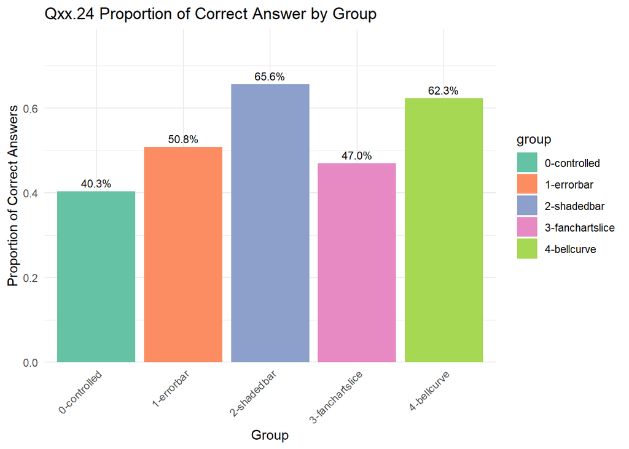

```r
ggplot(survey_q24_correct_prop, aes(x = group, y = proportion_correct, fill = group)) +
  geom_bar(stat = "identity") +
  geom_text(aes(label = scales::percent(proportion_correct, accuracy = 0.1)),
            vjust = -0.5, size = 3) +
  labs(
    title = "Qxx.24 Proportion of Correct Answer by Group",
    x = "Group",
    y = "Proportion of Correct Answers"
  ) +
    scale_y_continuous(
    expand = expansion(mult = c(0, 0.2))
  ) +
  scale_fill_brewer(palette = "Set2") +
  theme_minimal() +
  theme(axis.text.x = element_text(angle = 45, hjust = 1))
```

Visualisation Ranking

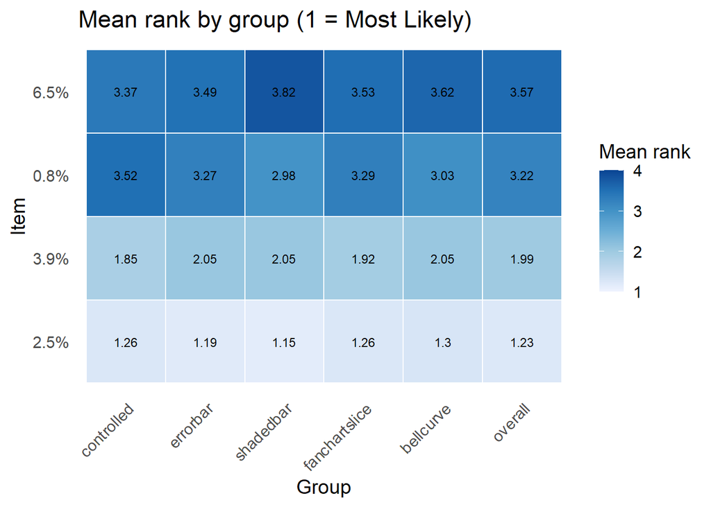

```r
df_long <- rank_summary %>%
  pivot_longer(-Item, names_to = "Group", values_to = "MeanRank") %>%
  mutate(
    # Order items by their overall best rank (smallest = best)
    Item  = factor(Item, levels = rank_summary %>% arrange(overall) %>% pull(Item)),
    # Keep groups in the order they appear in the data-frame
    Group = factor(Group, levels = names(rank_summary)[-1])
  )

ggplot(df_long, aes(Group, Item, fill = MeanRank)) +
  geom_tile(colour = "white", linewidth = .4) +
  geom_text(aes(label = round(MeanRank, 2)), size = 3) +
  scale_fill_distiller(palette = "Blues", direction = 1,
                       name = "Mean rank", limits = c(1, 4),
                       breaks = 1:4) +
  labs(title = "Mean rank by group (1 = Most Likely)") +
  theme_minimal(base_size = 14) +
  theme(panel.grid = element_blank(),
        axis.text.x = element_text(angle = 45, hjust = 1))
```

## Qxx.26 Accuracy of central estimate

On a scale of 1 to 10, where 1 means not accurate at all and 10 means very accurate, how accurate do you think the central estimate in the graph is?  
*1-Not accurate at all; 10-Very accurate*  
Variable: continuous  
Method: ANNOVA test or KW test (depends on whether it’s normally distributed)  
**Result: Fail to reject the null hypothesis.**

```r
# combine data from different groups
survey_q26 <- data.frame()
survey_q26_list <- list("Q4.26_1","Q6.26_1", "Q8.26_1", "Q10.26_1", "Q12.26_1")
for (i in seq_along(group_list)) {
  df <- group_list[[i]]
  col <- survey_q26_list[[i]]
  temp_table <- df[, c(col, "group", "treatment")]
  names(temp_table) <- c("q26_value", "group", "treatment")
  survey_q26 <- rbind(survey_q26, temp_table)
}
survey_q26$q26_value <- as.numeric(survey_q26$q26_value)
summary(survey_q26$q26_value)
```

```
##    Min. 1st Qu.  Median    Mean 3rd Qu.    Max.
##   1.000   6.000   7.000   6.421   7.000  10.000
```

Summary Table

```r
survey_q26_summary <- survey_q26 %>%
  group_by(group) %>%
  summarise(
    mean = mean(q26_value, na.rm = TRUE),
    median = median(q26_value, na.rm = TRUE),
    sd = sd(q26_value, na.rm = TRUE),
    IQR    = IQR(q26_value,   na.rm = TRUE),  # same as Q3 − Q1
    Q1     = quantile(q26_value, 0.25, na.rm = TRUE),
    Q3     = quantile(q26_value, 0.75, na.rm = TRUE)
  )
print(survey_q26_summary)
```

```
## # A tibble: 5 × 7
##   group            mean median    sd   IQR    Q1    Q3
##   <chr>           <dbl>  <dbl> <dbl> <dbl> <dbl> <dbl>
## 1 0-controlled     6.15      7  1.79  2     5        7
## 2 1-errorbar       6.41      7  1.60  1.5   5.5      7
## 3 2-shadedbar      6.64      7  1.60  2     6        8
## 4 3-fanchartslice  6.38      7  1.69  1.75  5.25     7
## 5 4-bellcurve      6.54      6  1.60  2     6        8
```

Statistical test

```r
# Initial Check
# summary(survey_q26$q26_value)

# check normality --> the data is not normally distributed
# shapiro.test(survey_q26$q26_value)

# run Kruskal-Wallis test
kruskal_test <- kruskal.test(q26_value ~ group, data = survey_q26)
print(kruskal_test)
```

```
##
##  Kruskal-Wallis rank sum test
##
## data:  q26_value by group
## Kruskal-Wallis chi-squared = 1.3483, df = 4, p-value = 0.8531
```

```r
# Effect size
kw_es  <- kruskal_effsize(q26_value ~ group, data = survey_q26, ci = TRUE)
print(kw_es)
```

```
## # A tibble: 1 × 7
##   .y.           n  effsize conf.low conf.high method  magnitude
## * <chr>     <int>    <dbl>    <dbl>     <dbl> <chr>   <ord>
## 1 q26_value   309 -0.00872    -0.01      0.04 eta2[H] small
```

Combine the treatment groups

```r
kruskal_test <- kruskal.test(q26_value ~ treatment, data = survey_q26)
print(kruskal_test)
```

```
##
##  Kruskal-Wallis rank sum test
##
## data:  q26_value by treatment
## Kruskal-Wallis chi-squared = 0.62468, df = 1, p-value = 0.4293
```

Plot the distribution of different groups

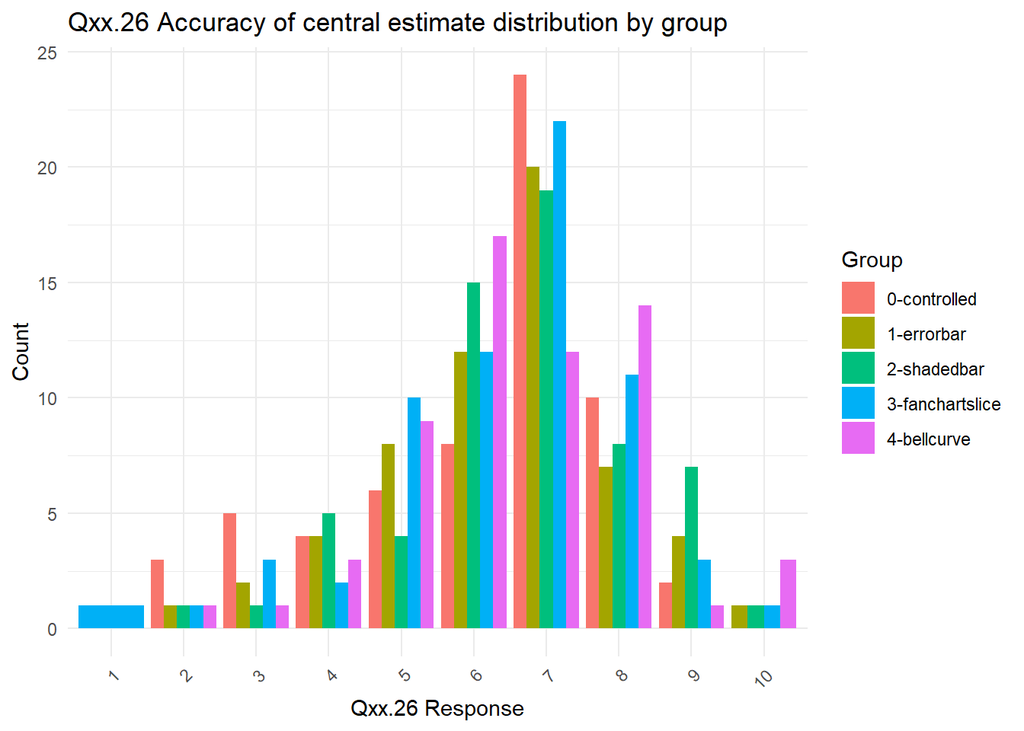

```r
# Grouped bar-style histogram\
ggplot(survey_q26, aes(x = factor(q26_value), fill = factor(group))) +
  geom_bar(position = "dodge") +
  # facet_wrap(~ group) +
  labs(
    title = "Qxx.26 Accuracy of central estimate distribution by group",
    x = "Qxx.26 Response",
    y = "Count",
    fill = "Group"
  ) +
  theme_minimal() +
  theme(axis.text.x = element_text(angle = 45, hjust = 1))
```

## Qxx.27 Certainty of central estimate

On a scale of 1 to 10, where 1 means very uncertain and 10 means very certain, how certain or uncertain do you think the inflation forecast for 2026 Q2 is?  
*1-Very uncertain; 10-Very certain*  
Variable: continuous  
Method: ANNOVA test or KW test (depends on whether it’s normally distributed)  
**Result: Fail to reject the null hypothesis.**

```r
# combine data from different groups
survey_q27 <- data.frame()
survey_q27_list <- list("Q4.27_1","Q6.27_1", "Q8.27_1", "Q10.27_1", "Q12.27_1")
for (i in seq_along(group_list)) {
  df <- group_list[[i]]
  col <- survey_q27_list[[i]]
  temp_table <- df[, c(col, "group", "treatment")]
  names(temp_table) <- c("q27_value", "group", "treatment")
  survey_q27 <- rbind(survey_q27, temp_table)
}
survey_q27$q27_value <- as.numeric(survey_q27$q27_value)
summary(survey_q27$q27_value)
```

```
##    Min. 1st Qu.  Median    Mean 3rd Qu.    Max.
##   1.000   5.000   6.000   5.838   7.000  10.000
```

Statistical test

```r
# Initial Check
# summary(survey_q27$q27_value)
# check normality --> the data is not normally distributed
# shapiro.test(survey_q27$q27_value)
# run Kruskal-Wallis test
kruskal_test <- kruskal.test(q27_value ~ group, data = survey_q27)
print(kruskal_test)
```

```
##
##  Kruskal-Wallis rank sum test
##
## data:  q27_value by group
## Kruskal-Wallis chi-squared = 0.99263, df = 4, p-value = 0.9109
```

```r
# Effect size
kw_es  <- kruskal_effsize(q27_value ~ group, data = survey_q27, ci = TRUE)
print(kw_es)
```

```
## # A tibble: 1 × 7
##   .y.           n  effsize conf.low conf.high method  magnitude
## * <chr>     <int>    <dbl>    <dbl>     <dbl> <chr>   <ord>
## 1 q27_value   309 -0.00989    -0.01      0.03 eta2[H] small
```

Combine the treatment groups

```r
kruskal_test <- kruskal.test(q27_value ~ treatment, data = survey_q27)
print(kruskal_test)
```

```
##
##  Kruskal-Wallis rank sum test
##
## data:  q27_value by treatment
## Kruskal-Wallis chi-squared = 0.056199, df = 1, p-value = 0.8126
```

Summary statistics

```r
# Summary statistics
survey_q27_summary <- survey_q27 %>%
  group_by(group) %>%
  summarise(
    mean = mean(q27_value, na.rm = TRUE),
    median = median(q27_value, na.rm = TRUE),
    sd = sd(q27_value, na.rm = TRUE),
    IQR    = IQR(q27_value,   na.rm = TRUE),  # same as Q3 − Q1
    Q1     = quantile(q27_value, 0.25, na.rm = TRUE),
    Q3     = quantile(q27_value, 0.75, na.rm = TRUE)
  )
print(survey_q27_summary)
```

```
## # A tibble: 5 × 7
##   group            mean median    sd   IQR    Q1    Q3
##   <chr>           <dbl>  <dbl> <dbl> <dbl> <dbl> <dbl>
## 1 0-controlled     5.85      6  1.84     2     5     7
## 2 1-errorbar       5.69      6  1.72     2     5     7
## 3 2-shadedbar      5.95      6  1.61     2     5     7
## 4 3-fanchartslice  5.91      6  1.80     2     5     7
## 5 4-bellcurve      5.77      6  1.69     2     5     7
```

Plot the distribution of different groups

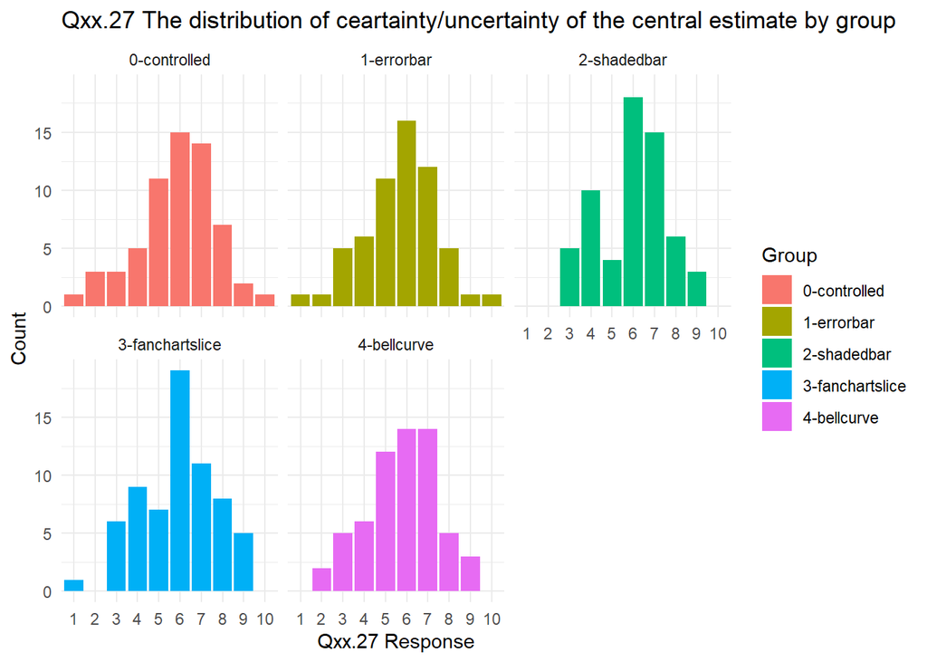

```r
# Grouped bar-style histogram
ggplot(survey_q27, aes(x = factor(q27_value), fill = factor(group))) +
  geom_bar(position = "dodge") +
  facet_wrap(~ group) +
  labs(
    title = "Qxx.27 The distribution of ceartainty/uncertainty of the central estimate by group",
    x = "Qxx.27 Response",
    y = "Count",
    fill = "Group"
  ) +
  theme_minimal()
```

## Qxx.28 Rationale for certainty/uncertainty of the forecast

Why do you think that the forecast is more or less uncertain? (Select all that apply)  
Variable: categorical  
Method: contingency table + Not comparable across group  
Function:

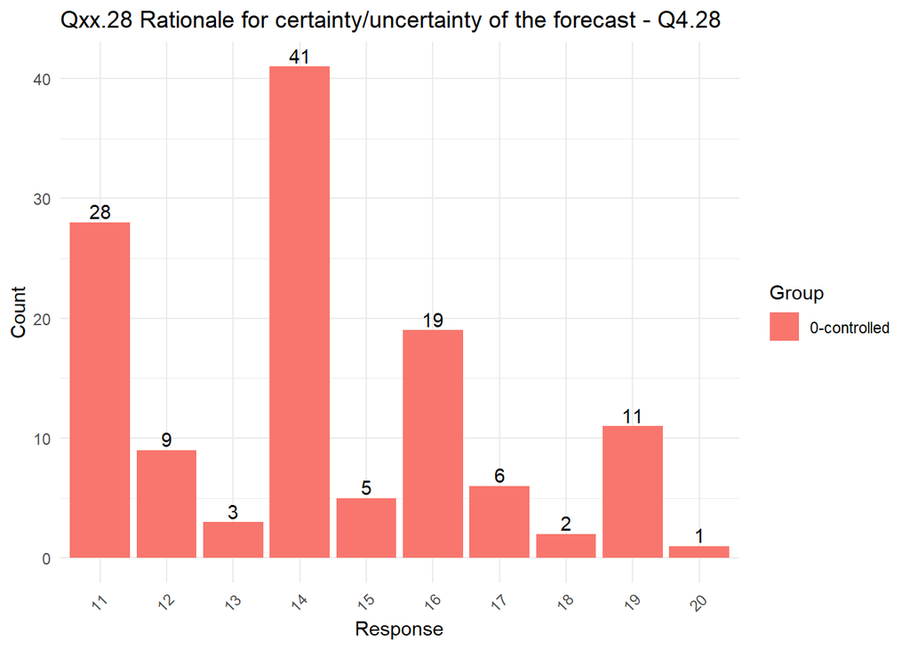

```r
plot_survey_q28 <- function(survey_data, question_header){
  survey_q28 <- survey_data %>%
    # select(all_of(question_header), group) %>%
    mutate(
      !!question_header := lapply(
        as.character(.data[[question_header]]),
        function(x) {
          if (is.na(x) || x == "") return(list())
          nums <- strsplit(x, ",")[[1]]
          as.list(as.numeric(trimws(nums)))
        }
      )
    ) %>%
    unnest(cols = all_of(question_header)) %>%
    group_by(group, value = .data[[question_header]]) %>%
    summarise(count = n(), .groups = "drop") %>%
    mutate(
      value = as.numeric(value)
    )
  # plot the bar chart
  ggplot(survey_q28, aes(x = factor(value), y = count, fill = group)) +
    geom_bar(stat = "identity", position = "dodge") +
    geom_text(aes(label = count), vjust = -0.25, position = position_dodge(0.9)) +
    labs(
      title = paste("Qxx.28 Rationale for certainty/uncertainty of the forecast -", question_header),
      x = "Response",
      y = "Count",
      fill = "Group"
    ) +
    theme_minimal() +
    theme(axis.text.x = element_text(angle = 45, hjust = 1))
  # return(survey_q28)
}

plot_survey_q28(controlled_group, "Q4.28")
```

## Qxx.29 Representativeness of the uncertainty

On a scale of 1 to 10, where 1 means not representative at all and 10 means very representative, how representative do you think the uncertainty being communicated is (i.e., how well the given information reflects the true variability or uncertainty of the forecast?)  
*1-Not representative at all; 10-Very representative*  
Variable: continuous  
Method: ANNOVA test or KW test (depends on whether it’s normally distributed)  
**Result: Fail to reject the null hypothesis.**

```r
# combine data from different groups
survey_q29 <- data.frame()
survey_q29_list <- list("Q4.29_1","Q6.29_1", "Q8.29_1", "Q10.29_1", "Q12.29_1")
for (i in seq_along(group_list)) {
  df <- group_list[[i]]
  col <- survey_q29_list[[i]]
  temp_table <- df[, c(col, "group", "treatment")]
  names(temp_table) <- c("q29_value", "group", "treatment")
  survey_q29 <- rbind(survey_q29, temp_table)
}
survey_q29$q29_value <- as.numeric(survey_q29$q29_value)
```

Statistical test

```r
# Initial Check
# summary(survey_q29$q29_value)
# check normality --> the data is not normally distributed
# shapiro.test(survey_q29$q29_value)
# run Kruskal-Wallis test
kruskal_test <- kruskal.test(q29_value ~ group, data = survey_q29)
print(kruskal_test)
```

```
##
##  Kruskal-Wallis rank sum test
##
## data:  q29_value by group
## Kruskal-Wallis chi-squared = 5.1458, df = 4, p-value = 0.2727
```

```r
# Effect size
kw_es  <- kruskal_effsize(q29_value ~ group, data = survey_q29, ci = TRUE)
print(kw_es)
```

```
## # A tibble: 1 × 7
##   .y.           n effsize conf.low conf.high method  magnitude
## * <chr>     <int>   <dbl>    <dbl>     <dbl> <chr>   <ord>
## 1 q29_value   309 0.00377  -0.0085      0.05 eta2[H] small
```

Combine the treatment groups

```r
kruskal_test <- kruskal.test(q29_value ~ treatment, data = survey_q29)
print(kruskal_test)
```

```
##
##  Kruskal-Wallis rank sum test
##
## data:  q29_value by treatment
## Kruskal-Wallis chi-squared = 0.047402, df = 1, p-value = 0.8276
```

Summary statistics

```r
# Summary statistics
survey_q29_summary <- survey_q29 %>%
  group_by(group) %>%
  summarise(
    mean = mean(q29_value, na.rm = TRUE),
    median = median(q29_value, na.rm = TRUE),
    sd = sd(q29_value, na.rm = TRUE),
    IQR    = IQR(q29_value,   na.rm = TRUE),  # same as Q3 − Q1
    Q1     = quantile(q29_value, 0.25, na.rm = TRUE),
    Q3     = quantile(q29_value, 0.75, na.rm = TRUE)
  )
```

Plot the distribution of different groups

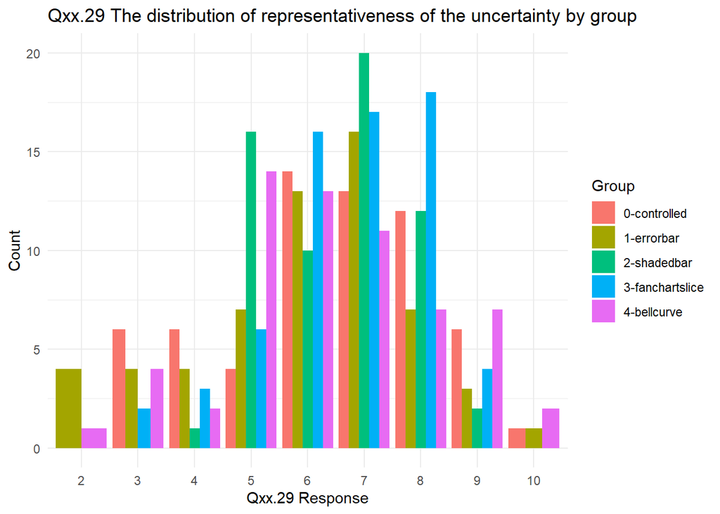

```r
# Grouped bar-style histogram
ggplot(survey_q29, aes(x = factor(q29_value), fill = factor(group))) +
  geom_bar(position = "dodge") +
  # facet_wrap(~ group) +
  labs(
    title = "Qxx.29 The distribution of representativeness of the uncertainty by group",
    x = "Qxx.29 Response",
    y = "Count",
    fill = "Group"
  ) +
  theme_minimal()
```

## ! Qxx.30 Readability of the Forecast

On a scale of 1 to 10, where 1 means very difficult and 10 means very easy, how easy or difficult do you find the graph to understand?  
*1-Very difficult; 10-Very easy*  
Variable: continuous  
Method: ANNOVA test or KW test (depends on whether it’s normally distributed)  
**Result: There are statistical difference between control group vs. fan chart slice group; control group vs. bell curve; error bar group vs. bell curve group.**

```r
# combine data from different groups
survey_q30 <- data.frame()
survey_q30_list <- list("Q4.30_1","Q6.30_1", "Q8.30_1", "Q10.30_1", "Q12.30_1")
for (i in seq_along(group_list)) {
  df <- group_list[[i]]
  col <- survey_q30_list[[i]]
  temp_table <- df[, c(col, "group","treatment")]
  names(temp_table) <- c("q30_value", "group", "treatment")
  survey_q30 <- rbind(survey_q30, temp_table)
}
survey_q30$q30_value <- as.numeric(survey_q30$q30_value)
```

Statistical test

```r
# Initial Check
# summary(survey_q30$q30_value)
# check normality --> the data is not normally distributed
# shapiro.test(survey_q30$q30_value)
# run Kruskal-Wallis test
kruskal_test <- kruskal.test(q30_value ~ group, data = survey_q30)
print(kruskal_test)
```

```
##
##  Kruskal-Wallis rank sum test
##
## data:  q30_value by group
## Kruskal-Wallis chi-squared = 21.14, df = 4, p-value = 0.0002971
```

```r
# Effect size
kw_es  <- kruskal_effsize(q30_value ~ group, data = survey_q30, ci = TRUE)
print(kw_es)
```

```
## # A tibble: 1 × 7
##   .y.           n effsize conf.low conf.high method  magnitude
## * <chr>     <int>   <dbl>    <dbl>     <dbl> <chr>   <ord>
## 1 q30_value   309  0.0564     0.02      0.13 eta2[H] small
```

```r
# Post-hoc test
dunnTest(q30_value ~ group, data = survey_q30, method = "bonferroni")
```

```
## Dunn (1964) Kruskal-Wallis multiple comparison
```

```
##   p-values adjusted with the Bonferroni method.
```

```
##                        Comparison         Z      P.unadj        P.adj
## 1       0-controlled - 1-errorbar 0.9304079 3.521599e-01 1.0000000000
## 2      0-controlled - 2-shadedbar 2.5337624 1.128452e-02 0.1128452320
## 3        1-errorbar - 2-shadedbar 1.5756957 1.150960e-01 1.0000000000
## 4  0-controlled - 3-fanchartslice 3.2161670 1.299152e-03 0.0129915217
## 5    1-errorbar - 3-fanchartslice 2.2303493 2.572426e-02 0.2572426134
## 6   2-shadedbar - 3-fanchartslice 0.6299386 5.287348e-01 1.0000000000
## 7      0-controlled - 4-bellcurve 3.9666282 7.289658e-05 0.0007289658
## 8        1-errorbar - 4-bellcurve 2.9908299 2.782205e-03 0.0278220451
## 9       2-shadedbar - 4-bellcurve 1.4270765 1.535579e-01 1.0000000000
## 10  3-fanchartslice - 4-bellcurve 0.8249587 4.093950e-01 1.0000000000
```

Summary statistics

```r
# Summary statistics
survey_q30_summary <- survey_q30 %>%
  group_by(group) %>%
  summarise(
    mean = mean(q30_value, na.rm = TRUE),
    median = median(q30_value, na.rm = TRUE),
    sd = sd(q30_value, na.rm = TRUE),
    IQR    = IQR(q30_value,   na.rm = TRUE),  # same as Q3 − Q1
    Q1     = quantile(q30_value, 0.25, na.rm = TRUE),
    Q3     = quantile(q30_value, 0.75, na.rm = TRUE)
  )
```

Plot the distribution of different groups

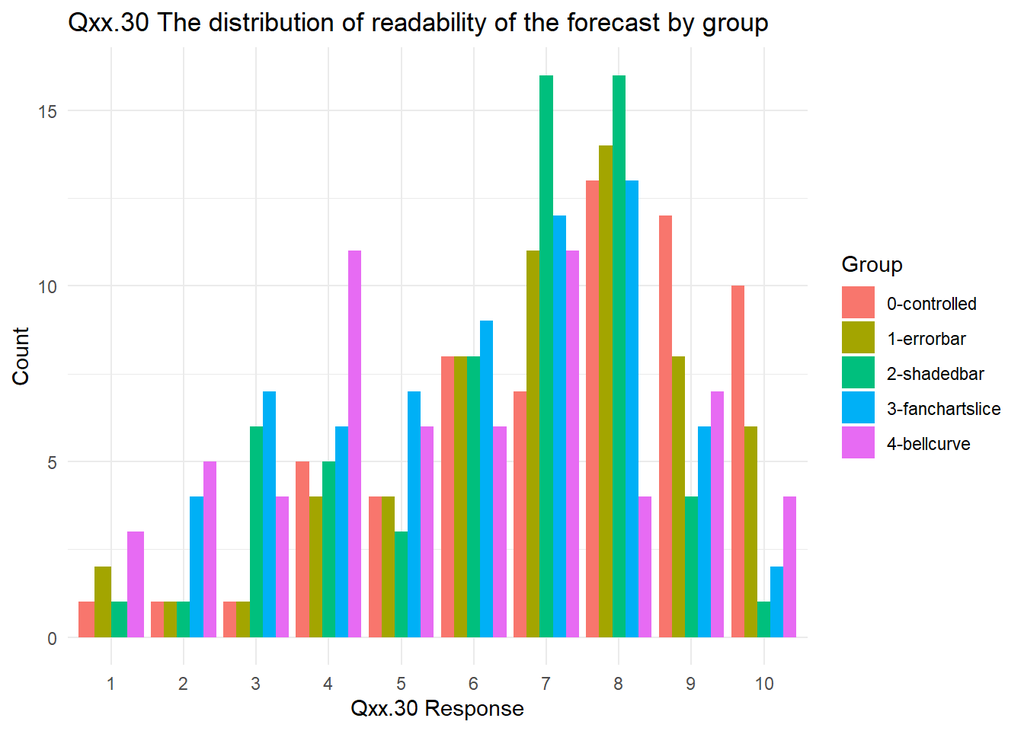

```r
# Grouped bar-style histogram
ggplot(survey_q30, aes(x = factor(q30_value), fill = factor(group))) +
  geom_bar(position = "dodge") +
  # facet_wrap(~ group) +
  labs(
    title = "Qxx.30 The distribution of readability of the forecast by group",
    x = "Qxx.30 Response",
    y = "Count",
    fill = "Group"
  ) +
  theme_minimal()
```

density plot

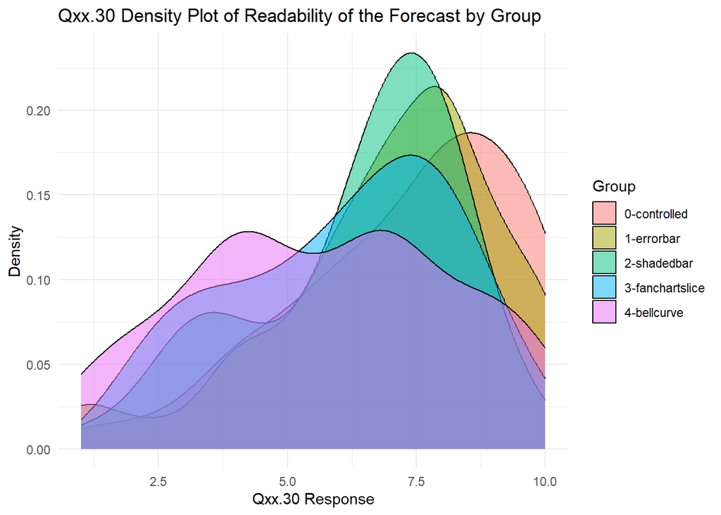

```r
# Density plot
ggplot(survey_q30, aes(x = q30_value, fill = group)) +
  geom_density(alpha = 0.5) +
  labs(
    title = "Qxx.30 Density Plot of Readability of the Forecast by Group",
    x = "Qxx.30 Response",
    y = "Density",
    fill = "Group"
  ) +
  theme_minimal()
```